# LendingClub 贷款数据分析及模型预测

## 目录

- 项目背景和目的
  - 项目背景
  - 项目目的
- 数据获取、清洗和整理
  - 数据获取
  - 数据清洗和整理
    - 合并数据集
    - 检查缺失值
    - 检查重复值
    - 处理只有单一数值或属性的变量
    - 筛选个人贷款数据
    - 筛选进行探索分析的变量
    - 转换数据类型
    - 插入缺失值
- 贷款数据探索分析
  - 平台个人贷款业务规模和业务特点分析
    - 个人贷款业务规模趋势分析（贷款金额、贷款笔数、平均每笔贷款金额）
    - 个人贷款业务特点分析（贷款金额、贷款期限、贷款信用评级、贷款利率、贷款状态）
    - 平台个人贷款业务总结
  - 平台贷款客户特征分析
    - 平台贷款客户基本情况分析（地域分布、职业分布、工作年限、年收入分布、债务收入比、房屋所有权状况、收入认证状态）
    - 平台贷款客户行为状况分析（贷款原因、征信查询次数、欠款账户数量、逾期违约次数、贷款坏账冲销次数）
    - 平台贷款客户特征总结
  - 贷款违约影响因素分析
    - 贷款金额、期限、利率、信用评级与违约贷款的关系
    - 客户收入状况与违约贷款的关系
    - 客户工作年限、房屋所有权状况与违约贷款的关系
    - 客户资金状况与违约贷款的关系
    - 客户信用记录与违约贷款的关系
    - 贷款违约影响因素分析总结
- 构建贷款违约预测模型
  - 算法选择
    - 逻辑回归算法
  - 数据处理
    - 数据类型转换
    - 缺失值处理
  - 模型特征选择
    - 递归特征消除
    - 皮尔逊相关系数
  - 建立训练数据集和测试数据集
  - 模型训练
    - 处理样本不均衡
    - 交叉验证
  - 模型评估
    - 混淆矩阵
- 总结及建议
  - 总结
  - 建议

## 一、项目背景和目的

### 1.1 项目背景：

- LendingClub是美国规模最大的P2P网贷平台，创立于2006年，总部位于旧金山，2014年12月在纽约证券交易所上市，成为当年最大的科技股IPO。LendingClub以互联网金融创新模式建立了一个比传统借贷机构更高效的在线交易平台，投资和贷款流程高度自动化，利用在线数据和技术快速评估风险，确定贷款信用评级和利率，检测欺诈风险。通过LendingClub平台，投资者可选择多元化投资组合，获得具竞争力的回报，贷款人则可获得较低的贷款利率，降低借贷成本。

### 1.2 项目目的：

- LendingClub标准个人贷款服务的申请类型包括单一借款人和联合借款人，本项目针对单一借款人的个人贷款业务数据进行探索分析，下文提及的“个人贷款”均指单一借款人的个人贷款，项目目的为解决以下问题：
  - 了解LendingClub个人贷款服务的业务规模和业务特点
  - 了解平台贷款客户特征，包括客户基本情况和行为状况
  - 了解贷款违约的影响因素
  - 构建模型预测贷款是否会违约
  - 提出建议

## 二、数据获取、清洗和整理

### 2.1 数据获取：

- 本项目数据为LendingClub2018年第一季度和第二季度的个人贷款业务数据，包含更新至2018年8月的贷款状态信息，原始数据集于LendingClub官网下载。

### 2.2 数据清洗和整理：

```python
import numpy as np
import pandas as pd
import matplotlib.pyplot as plt
%matplotlib inline
plt.style.use('ggplot')
plt.rcParams['font.sans-serif'] = ['SimHei']
plt.rcParams['axes.unicode_minus'] = False
import seaborn as sns
import warnings
warnings.filterwarnings('ignore')
```

#### 2.2.1 导入数据，数据概览

```python
LoanStats_2018Q1 = pd.read_csv('LoanStats_2018Q1.csv',encoding='utf8',skiprows=1,low_memory=False)
LoanStats_2018Q2 = pd.read_csv('LoanStats_2018Q2.csv',encoding='utf8',skiprows=1,low_memory=False)
```

```python
LoanStats_2018Q1.head()
```

|  | id | member_id | loan_amnt | funded_amnt | funded_amnt_inv | term | int_rate | installment | grade | sub_grade | ... | hardship_payoff_balance_amount | hardship_last_payment_amount | disbursement_method | debt_settlement_flag | debt_settlement_flag_date | settlement_status | settlement_date | settlement_amount | settlement_percentage | settlement_term |
| --- | --- | --- | --- | --- | --- | --- | --- | --- | --- | --- | --- | --- | --- | --- | --- | --- | --- | --- | --- | --- | --- |
| 0 | NaN | NaN | 7200.0 | 7200.0 | 7200.0 | 36 months | 13.58% | 244.62 | C | C2 | ... | NaN | NaN | Cash | N | NaN | NaN | NaN | NaN | NaN | NaN |
| 1 | NaN | NaN | 12000.0 | 12000.0 | 12000.0 | 36 months | 6.07% | 365.45 | A | A2 | ... | NaN | NaN | Cash | N | NaN | NaN | NaN | NaN | NaN | NaN |
| 2 | NaN | NaN | 3100.0 | 3100.0 | 3100.0 | 36 months | 9.43% | 99.21 | B | B1 | ... | NaN | NaN | Cash | N | NaN | NaN | NaN | NaN | NaN | NaN |
| 3 | NaN | NaN | 3200.0 | 3200.0 | 3200.0 | 36 months | 7.96% | 100.22 | A | A5 | ... | NaN | NaN | Cash | N | NaN | NaN | NaN | NaN | NaN | NaN |
| 4 | NaN | NaN | 11000.0 | 11000.0 | 11000.0 | 36 months | 7.34% | 341.37 | A | A4 | ... | NaN | NaN | Cash | N | NaN | NaN | NaN | NaN | NaN | NaN |

5 rows × 145 columns

```python
LoanStats_2018Q2.head()
```

|  | id | member_id | loan_amnt | funded_amnt | funded_amnt_inv | term | int_rate | installment | grade | sub_grade | ... | hardship_payoff_balance_amount | hardship_last_payment_amount | disbursement_method | debt_settlement_flag | debt_settlement_flag_date | settlement_status | settlement_date | settlement_amount | settlement_percentage | settlement_term |
| --- | --- | --- | --- | --- | --- | --- | --- | --- | --- | --- | --- | --- | --- | --- | --- | --- | --- | --- | --- | --- | --- |
| 0 | NaN | NaN | 12000.0 | 12000.0 | 12000.0 | 60 months | 19.42% | 314.07 | D | D3 | ... | NaN | NaN | Cash | N | NaN | NaN | NaN | NaN | NaN | NaN |
| 1 | NaN | NaN | 35000.0 | 35000.0 | 35000.0 | 60 months | 22.90% | 984.66 | E | E1 | ... | NaN | NaN | Cash | N | NaN | NaN | NaN | NaN | NaN | NaN |
| 2 | NaN | NaN | 8000.0 | 8000.0 | 8000.0 | 36 months | 6.83% | 246.40 | A | A3 | ... | NaN | NaN | Cash | N | NaN | NaN | NaN | NaN | NaN | NaN |
| 3 | NaN | NaN | 14000.0 | 14000.0 | 14000.0 | 60 months | 10.56% | 301.34 | B | B3 | ... | NaN | NaN | Cash | N | NaN | NaN | NaN | NaN | NaN | NaN |
| 4 | NaN | NaN | 22000.0 | 22000.0 | 22000.0 | 60 months | 17.47% | 552.34 | D | D1 | ... | NaN | NaN | DirectPay | N | NaN | NaN | NaN | NaN | NaN | NaN |

5 rows × 145 columns

```python
LoanStats_2018Q1.info()
```

```
<class 'pandas.core.frame.DataFrame'>
RangeIndex: 107866 entries, 0 to 107865
Columns: 145 entries, id to settlement_term
dtypes: float64(107), object(38)
memory usage: 119.3+ MB
```

```python
LoanStats_2018Q2.info()
```

```
<class 'pandas.core.frame.DataFrame'>
RangeIndex: 130774 entries, 0 to 130773
Columns: 145 entries, id to settlement_term
dtypes: float64(114), object(31)
memory usage: 144.7+ MB
```

```python
a = set(LoanStats_2018Q1.select_dtypes(include=['object']).columns)
b = set(LoanStats_2018Q2.select_dtypes(include=['object']).columns)
c = list(a-b)
for col in c:
    print(col,'isnull_pct:',LoanStats_2018Q2[col].isnull().sum()/len(LoanStats_2018Q2))
```

```
hardship_end_date isnull_pct: 1.0
hardship_status isnull_pct: 1.0
hardship_loan_status isnull_pct: 1.0
payment_plan_start_date isnull_pct: 1.0
hardship_type isnull_pct: 1.0
hardship_start_date isnull_pct: 1.0
hardship_reason isnull_pct: 1.0
```

- 2018年第一季度贷款数据集共有107866行、145个变量，第二季度共有130774行、145个变量，数据类型为浮点数和字符串类型，第一季度与第二季度的分类变量相差7个，检查发现是由于第二季度的这7列数据全为缺失值NaN导致。

#### 2.2.2 合并数据集

```python
LoanStats_2018Q1Q2 = pd.concat([LoanStats_2018Q1,LoanStats_2018Q2])
```

```python
LoanStats_2018Q1Q2.reset_index(drop=True,inplace=True)
```

```python
LoanStats_2018Q1Q2.shape
```

```
(238640, 145)
```

- 两份原始数据集变量相同，结构一致，合并数据集后，共有238640行，145列。

#### 2.2.3 检查缺失值

```python
isnull_col = LoanStats_2018Q1Q2.isnull().sum().sort_values(ascending=False)/len(LoanStats_2018Q1Q2)
print('isnull_col_count:',isnull_col.count())
isnull_col[isnull_col >= 0.5]
```

```
isnull_col_count: 145
```

```
member_id                                     1.000000
url                                           1.000000
desc                                          1.000000
hardship_payoff_balance_amount                0.999992
hardship_loan_status                          0.999992
hardship_amount                               0.999992
hardship_start_date                           0.999992
hardship_end_date                             0.999992
payment_plan_start_date                       0.999992
hardship_length                               0.999992
hardship_dpd                                  0.999992
deferral_term                                 0.999992
orig_projected_additional_accrued_interest    0.999992
hardship_status                               0.999992
hardship_last_payment_amount                  0.999992
hardship_reason                               0.999992
hardship_type                                 0.999992
id                                            0.999983
settlement_percentage                         0.999920
settlement_term                               0.999920
settlement_status                             0.999920
settlement_amount                             0.999920
debt_settlement_flag_date                     0.999920
settlement_date                               0.999920
sec_app_mths_since_last_major_derog           0.951345
mths_since_last_record                        0.866632
verification_status_joint                     0.859898
sec_app_revol_util                            0.858410
sec_app_earliest_cr_line                      0.855774
annual_inc_joint                              0.855774
revol_bal_joint                               0.855774
dti_joint                                     0.855774
sec_app_inq_last_6mths                        0.855774
sec_app_num_rev_accts                         0.855774
sec_app_mort_acc                              0.855774
sec_app_chargeoff_within_12_mths              0.855774
sec_app_collections_12_mths_ex_med            0.855774
sec_app_open_act_il                           0.855774
sec_app_open_acc                              0.855774
mths_since_recent_bc_dlq                      0.800888
mths_since_last_major_derog                   0.766079
mths_since_recent_revol_delinq                0.711586
mths_since_last_delinq                        0.557622
dtype: float64
```

- 检查缺失值，发现数据集有145列存在缺失值，即每一列数据都有缺失；
- 检查发现缺失值超过50%的变量主要是贷后数据和联合借款人信息，对分析意义不大，可以删除。

```python
LoanStats_2018Q1Q2.dropna(axis=1,thresh=len(LoanStats_2018Q1Q2)*0.5,inplace=True)
```

```python
LoanStats_2018Q1Q2.loc[LoanStats_2018Q1Q2.loan_amnt.isnull()]
```

|  | loan_amnt | funded_amnt | funded_amnt_inv | term | int_rate | installment | grade | sub_grade | emp_title | emp_length | ... | percent_bc_gt_75 | pub_rec_bankruptcies | tax_liens | tot_hi_cred_lim | total_bal_ex_mort | total_bc_limit | total_il_high_credit_limit | hardship_flag | disbursement_method | debt_settlement_flag |
| --- | --- | --- | --- | --- | --- | --- | --- | --- | --- | --- | --- | --- | --- | --- | --- | --- | --- | --- | --- | --- | --- |
| 107864 | NaN | NaN | NaN | NaN | NaN | NaN | NaN | NaN | NaN | NaN | ... | NaN | NaN | NaN | NaN | NaN | NaN | NaN | NaN | NaN | NaN |
| 107865 | NaN | NaN | NaN | NaN | NaN | NaN | NaN | NaN | NaN | NaN | ... | NaN | NaN | NaN | NaN | NaN | NaN | NaN | NaN | NaN | NaN |
| 238638 | NaN | NaN | NaN | NaN | NaN | NaN | NaN | NaN | NaN | NaN | ... | NaN | NaN | NaN | NaN | NaN | NaN | NaN | NaN | NaN | NaN |
| 238639 | NaN | NaN | NaN | NaN | NaN | NaN | NaN | NaN | NaN | NaN | ... | NaN | NaN | NaN | NaN | NaN | NaN | NaN | NaN | NaN | NaN |

4 rows × 102 columns

- 检查发现有四行数据全部缺失，正是导致数据集每一列数据都有缺失值的原因，将其删除。

```python
LoanStats_2018Q1Q2.drop([107864,107865,238638,238639],inplace=True)
```

```python
LoanStats_2018Q1Q2.shape
```

```
(238636, 102)
```

- 初步处理缺失值后，数据集共有238636行、102列。

#### 2.2.4 检查重复值

```python
LoanStats_2018Q1Q2.duplicated().value_counts()
```

```
False    238636
dtype: int64
```

- 因为数据集不存在唯一标识的变量，所有变量都一致的行数据才作重复数据，数据集不存在重复行数据。

#### 2.2.5 处理只有单一数值或属性的变量

```python
columns = []
for col in LoanStats_2018Q1Q2.columns:
    count = LoanStats_2018Q1Q2[col].nunique()
    if count == 1:
        columns.append(col)
print(columns)
```

```
['policy_code', 'num_tl_120dpd_2m']
```

```python
for col in columns:
    print(col)
    print(LoanStats_2018Q1Q2[col].value_counts())
    print('***'*5)
```

```
policy_code
1.0    238636
Name: policy_code, dtype: int64
***************
num_tl_120dpd_2m
0.0    232345
Name: num_tl_120dpd_2m, dtype: int64
***************
```

- 检查只有单一数值或属性的变量，对分析意义不大，可删除。
  - policy_code：均为1，表示公开数据；
  - num_tl_120dpd_2m：均为0，而且存在缺失值，表示当前120天到期的帐户数量（过去2个月更新）。

```python
LoanStats_2018Q1Q2.drop(columns,axis=1,inplace=True)
```

```python
LoanStats_2018Q1Q2.shape
```

```
(238636, 100)
```

#### 2.2.6 筛选申请类型为单一借款人的个人贷款数据

```python
LoanStats_2018Q1Q2_Individual = LoanStats_2018Q1Q2.loc[LoanStats_2018Q1Q2.application_type =='Individual']
```

```python
LoanStats_2018Q1Q2_Individual.select_dtypes(include=['object']).describe().T.assign(isnull_pct = LoanStats_2018Q1Q2_Individual.isnull().sum()/len(LoanStats_2018Q1Q2_Individual))
```

|  | count | unique | top | freq | isnull_pct |
| --- | --- | --- | --- | --- | --- |
| term | 204218 | 2 | 36 months | 146863 | 0.000000 |
| int_rate | 204218 | 75 | 5.31% | 7343 | 0.000000 |
| grade | 204218 | 7 | B | 60931 | 0.000000 |
| sub_grade | 204218 | 35 | B5 | 13083 | 0.000000 |
| emp_title | 188916 | 64216 | Manager | 3636 | 0.074930 |
| emp_length | 204218 | 12 | 10+ years | 68129 | 0.000000 |
| home_ownership | 204218 | 4 | MORTGAGE | 91415 | 0.000000 |
| verification_status | 204218 | 3 | Source Verified | 85098 | 0.000000 |
| issue_d | 204218 | 6 | May-2018 | 39993 | 0.000000 |
| loan_status | 204218 | 6 | Current | 189345 | 0.000000 |
| pymnt_plan | 204218 | 2 | n | 204217 | 0.000000 |
| purpose | 204218 | 13 | debt_consolidation | 99818 | 0.000000 |
| title | 204218 | 12 | Debt consolidation | 99818 | 0.000000 |
| zip_code | 204218 | 882 | 112xx | 2406 | 0.000000 |
| addr_state | 204218 | 50 | CA | 27976 | 0.000000 |
| earliest_cr_line | 204218 | 655 | Aug-2006 | 1712 | 0.000000 |
| revol_util | 203992 | 1089 | 0% | 2166 | 0.001107 |
| initial_list_status | 204218 | 2 | w | 172583 | 0.000000 |
| last_pymnt_d | 203910 | 8 | Aug-2018 | 191037 | 0.001508 |
| next_pymnt_d | 193069 | 3 | Sep-2018 | 193022 | 0.054594 |
| last_credit_pull_d | 204217 | 11 | Aug-2018 | 196356 | 0.000005 |
| application_type | 204218 | 1 | Individual | 204218 | 0.000000 |
| hardship_flag | 204218 | 2 | N | 204217 | 0.000000 |
| disbursement_method | 204218 | 2 | Cash | 183532 | 0.000000 |
| debt_settlement_flag | 204218 | 2 | N | 204201 | 0.000000 |

- 将数据集中包含重复信息或贷后信息的分类变量和数值变量删除。

```python
LoanStats_2018Q1Q2_Individual.drop(['sub_grade','purpose','pymnt_plan','zip_code','earliest_cr_line','initial_list_status','last_pymnt_d',
                    'next_pymnt_d','last_credit_pull_d','hardship_flag','disbursement_method','debt_settlement_flag'],axis=1,inplace=True)
```

```python
LoanStats_2018Q1Q2_Individual.drop(['funded_amnt','funded_amnt_inv','out_prncp','out_prncp_inv','total_pymnt','total_pymnt_inv',
                                    'total_rec_prncp','total_rec_int','total_rec_late_fee','recoveries','collection_recovery_fee',
                                    'last_pymnt_amnt'],axis=1,inplace=True)
```

```python
LoanStats_2018Q1Q2_Individual.shape
```

```
(204218, 76)
```

- 筛选数据后，单一借款人的个人贷款数据集共有204218行和76列，导出CSV文件保存。

```python
LoanStats_2018Q1Q2_Individual.to_csv('LoanStats_2018Q1Q2_Individual.csv',encoding='utf8',index=False)
```

#### 2.2.7 筛选进行探索分析的变量

```python
chosen_col = ['loan_amnt','term','int_rate','installment','grade','emp_title','emp_length','home_ownership','annual_inc','verification_status',
            'issue_d','loan_status','title','addr_state','dti','delinq_2yrs','inq_last_6mths','chargeoff_within_12_mths','acc_now_delinq']
```

```python
loan_2018Q1Q2 = LoanStats_2018Q1Q2_Individual[chosen_col]
```

- 本报告选取以下变量进行探索分析：
  - loan_amnt：贷款金额，单位为美元
  - term：贷款期限，单位为月
  - int_rate：贷款利率
  - installment：贷款客户每月还款金额（本金和利息）
  - grade：贷款信用评级
  - emp_title：贷款客户职业
  - emp_length：贷款客户工作年限
  - home_ownership：贷款客户房屋所有权状况
  - annual_inc：贷款客户年收入，单位为美元
  - verification_status：收入认证状态
  - issue_d：发放贷款的月份
  - loan_status：贷款状态
  - title：贷款原因
  - addr_state：贷款客户所在州
  - dti：债务收入比，贷款客户每月债务偿还总额（不包括抵押贷款和申请的LendingClub贷款）除以月收入的比率
  - delinq_2yrs：贷款客户最近2年逾期30天以上的违约次数
  - inq_last_6mths：贷款客户最近6个月的征信查询次数（不包括汽车及按揭查询）
  - chargeoff_within_12_mths：贷款客户12个月内贷款坏账冲销的次数
  - acc_now_delinq：贷款客户目前欠款的账户数量

#### 2.2.8 转换数据类型

```python
loan_2018Q1Q2.select_dtypes(include=['object']).columns
```

```
Index(['term', 'int_rate', 'grade', 'emp_title', 'emp_length',
       'home_ownership', 'verification_status', 'issue_d', 'loan_status',
       'title', 'addr_state'],
      dtype='object')
```

```python
loan_2018Q1Q2.int_rate = LoanStats_2018Q1Q2.int_rate.str.rstrip('%').astype('float')
```

```python
loan_2018Q1Q2.issue_d = pd.to_datetime(LoanStats_2018Q1Q2.issue_d).apply(lambda x:x.to_period('M'))
```

- 分类变量中，贷款利率和发放贷款的月份需分别转换为浮点数和时期类型数据。

```python
loan_2018Q1Q2.select_dtypes(include=[np.number]).columns
```

```
Index(['loan_amnt', 'int_rate', 'installment', 'annual_inc', 'dti',
       'delinq_2yrs', 'inq_last_6mths', 'chargeoff_within_12_mths',
       'acc_now_delinq'],
      dtype='object')
```

```python
loan_2018Q1Q2.delinq_2yrs = LoanStats_2018Q1Q2.delinq_2yrs.astype(int)
loan_2018Q1Q2.inq_last_6mths = LoanStats_2018Q1Q2.inq_last_6mths.astype(int)
loan_2018Q1Q2.acc_now_delinq = LoanStats_2018Q1Q2.acc_now_delinq.astype(int)
loan_2018Q1Q2.chargeoff_within_12_mths = LoanStats_2018Q1Q2.chargeoff_within_12_mths.astype(int)
```

- 数值变量中，将逾期违约次数、征信查询次数、贷款坏账冲销次数和欠款账户数量转换为整数。

#### 2.2.9 插入缺失值

```python
loan_2018Q1Q2.emp_title.fillna('unknown',inplace=True)
```

- 贷款客户职业属性中存在缺失值，以'unknown'补全。

#### 2.2.10 分析数据集概览和导出

```python
loan_2018Q1Q2.info()
```

```
<class 'pandas.core.frame.DataFrame'>
Int64Index: 204218 entries, 0 to 238637
Data columns (total 19 columns):
loan_amnt                   204218 non-null float64
term                        204218 non-null object
int_rate                    204218 non-null float64
installment                 204218 non-null float64
grade                       204218 non-null object
emp_title                   204218 non-null object
emp_length                  204218 non-null object
home_ownership              204218 non-null object
annual_inc                  204218 non-null float64
verification_status         204218 non-null object
issue_d                     204218 non-null object
loan_status                 204218 non-null object
title                       204218 non-null object
addr_state                  204218 non-null object
dti                         204218 non-null float64
delinq_2yrs                 204218 non-null int32
inq_last_6mths              204218 non-null int32
chargeoff_within_12_mths    204218 non-null int32
acc_now_delinq              204218 non-null int32
dtypes: float64(5), int32(4), object(10)
memory usage: 38.0+ MB
```

- 分析数据集共有204218行，19个变量，不存在缺失值，导出为CSV文件保存。

```python
loan_2018Q1Q2.to_csv('Loan_2018Q1Q2_EDA.csv',encoding='utf8',index=False)
```

## 三、贷款数据探索分析

```python
loan = pd.read_csv('Loan_2018Q1Q2_EDA.csv',encoding='utf8')
```

```python
loan.head()
```

|  | loan_amnt | term | int_rate | installment | grade | emp_title | emp_length | home_ownership | annual_inc | verification_status | issue_d | loan_status | title | addr_state | dti | delinq_2yrs | inq_last_6mths | chargeoff_within_12_mths | acc_now_delinq |
| --- | --- | --- | --- | --- | --- | --- | --- | --- | --- | --- | --- | --- | --- | --- | --- | --- | --- | --- | --- |
| 0 | 7200.0 | 36 months | 13.58 | 244.62 | C | Electronic Health Services trainer | 8 years | RENT | 51738.0 | Source Verified | 2018-03 | Current | Debt consolidation | OR | 6.87 | 0 | 2 | 0 | 0 |
| 1 | 12000.0 | 36 months | 6.07 | 365.45 | A | Associate Vice President | 10+ years | MORTGAGE | 240000.0 | Source Verified | 2018-03 | Current | Credit card refinancing | CT | 10.99 | 0 | 0 | 0 | 0 |
| 2 | 3100.0 | 36 months | 9.43 | 99.21 | B | Manager | 10+ years | MORTGAGE | 85000.0 | Not Verified | 2018-03 | Current | Vacation | GA | 9.12 | 1 | 1 | 0 | 0 |
| 3 | 3200.0 | 36 months | 7.96 | 100.22 | A | Lineman | 1 year | RENT | 42000.0 | Source Verified | 2018-03 | Current | Debt consolidation | NY | 6.94 | 0 | 1 | 0 | 0 |
| 4 | 11000.0 | 36 months | 7.34 | 341.37 | A | MPF | 10+ years | OWN | 100000.0 | Not Verified | 2018-03 | Current | Debt consolidation | WA | 24.95 | 0 | 1 | 0 | 0 |

```python
loan.info()
```

```
<class 'pandas.core.frame.DataFrame'>
RangeIndex: 204218 entries, 0 to 204217
Data columns (total 19 columns):
loan_amnt                   204218 non-null float64
term                        204218 non-null object
int_rate                    204218 non-null float64
installment                 204218 non-null float64
grade                       204218 non-null object
emp_title                   204218 non-null object
emp_length                  204218 non-null object
home_ownership              204218 non-null object
annual_inc                  204218 non-null float64
verification_status         204218 non-null object
issue_d                     204218 non-null object
loan_status                 204218 non-null object
title                       204218 non-null object
addr_state                  204218 non-null object
dti                         204218 non-null float64
delinq_2yrs                 204218 non-null int64
inq_last_6mths              204218 non-null int64
chargeoff_within_12_mths    204218 non-null int64
acc_now_delinq              204218 non-null int64
dtypes: float64(5), int64(4), object(10)
memory usage: 29.6+ MB
```

### 3.1 平台个人贷款业务规模和业务特点分析

#### 3.1.1 个人贷款业务规模趋势分析

- 从贷款金额、贷款笔数、平均每笔贷款金额三个维度展开分析。

```python
month_amount = loan.groupby('issue_d').loan_amnt.sum()
month_count = loan.groupby('issue_d').loan_amnt.count()
month = list(month_amount.index)
```

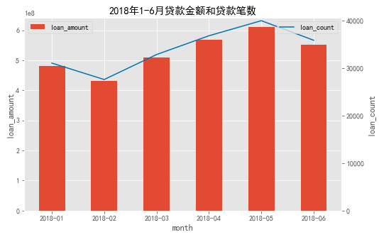

```python
plt.figure(figsize=(8,5))
plt.title('2018年1-6月贷款金额和贷款笔数')
plt.bar(month,month_amount,label='loan_amount',width = 0.5)
plt.ylabel('loan_amount')
plt.xlabel('month')
plt.legend(loc=2)

plt.twinx()
plt.plot(month,month_count,color='#0072B2',label='loan_count')
plt.ylabel('loan_count')
plt.grid(False)
plt.yticks([0,10000,20000,30000,40000])
plt.legend(loc=1)
plt.show()
```

- 根据月度贷款金额趋势图显示，2018年1-6月平台个人贷款金额呈波动增长趋势。
- 由季度业绩报告可知，平台2018年第一季度放贷总额比2017年第四季度减少5%；受季节性因素影响，2018年第一季度美国个人消费支出增长放缓，平台2月份个人贷款金额4.32亿美元，较1月份4.8亿美元，环比下降10%，3月份逐渐回升至5.1亿美元，环比增长18%。
- 2018年第二季度美国经济保持增长态势，消费信贷规模逐步扩张，平台第二季度个人贷款金额17.31亿美元，较第一季度14.23亿美元，环比增长22%，5月份贷款金额最高，达到6.11亿美元。
- 截至2018年6月份，平台个人贷款业务累计贷款金额为31.54亿美元，占上半年放贷总额的62%。
- 由月度贷款笔数趋势图可知，2018年1-6月平台个人贷款笔数呈波动增长趋势，与月度贷款金额走势一致，每月贷款笔数在2.7-4万之间，第二季度贷款笔数为11.27万，第一季度贷款笔数为9.15万，环比增长23%。

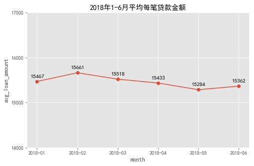

```python
plt.figure(figsize=(8,5))
plt.title('2018年1-6月平均每笔贷款金额')
plt.plot(month,month_amount/month_count,'-o')
plt.xlabel('month')
plt.ylabel('avg_loan_amount')
plt.yticks([14000,15000,16000,17000])
for x,y in zip(month,month_amount/month_count):
    plt.text(x,y+80,'%.0f'%y,ha='center',fontsize=11)
plt.show()
```

- 2018年1-6月平均每笔贷款金额比较稳定，均为1.55万美元左右，波动小，可见平台个人贷款业务属于小额贷款服务。

#### 3.1.2 个人贷款业务特点分析

- 从贷款金额、贷款期限、贷款信用评级、贷款利率、贷款状态五个维度展开分析。

```python
loan.describe()[['loan_amnt']].T
```

|  | count | mean | std | min | 25% | 50% | 75% | max |
| --- | --- | --- | --- | --- | --- | --- | --- | --- |
| loan_amnt | 204218.0 | 15441.055025 | 9932.593591 | 1000.0 | 8000.0 | 12500.0 | 20000.0 | 40000.0 |

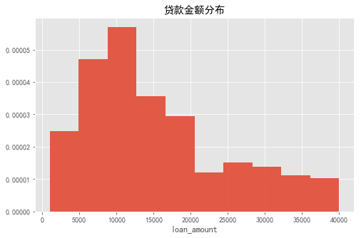

```python
plt.figure(figsize=(8,5))
plt.hist(loan.loan_amnt,bins=10,alpha=0.9,normed=1)
plt.title('贷款金额分布')
plt.xlabel('loan_amount')
plt.show()
```

- 平台个人贷款业务的贷款额度为1000美元至40000美元；
- 平均每笔贷款金额为15441美元，中位数为12500美元，金额不超过20000美元的个人贷款业务占比75%；
- 贷款金额呈右偏分布，业务主要集中于较低的额度档次，部分业务贷款金额较高，平台个人贷款服务以小额贷款为主。

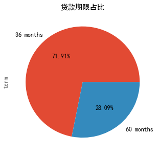

```python
term_percentage = loan.term.value_counts()/len(loan.term)
term_percentage.plot.pie(figsize=(5,5),autopct='%1.2f%%',fontsize=12)
plt.title('贷款期限占比')
plt.show()
```

- 平台个人贷款业务的贷款期限分为36个月和60个月，占比分别为71.91%、28.09%；
- 不同贷款期限的信用风险不同，贷款期限越长，信用风险越大，平台更偏向于低风险的3年期贷款。

```python
loan.groupby('term').loan_amnt.describe()
```

| term | count | mean | std | min | 25% | 50% | 75% | max |
| --- | --- | --- | --- | --- | --- | --- | --- | --- |
| 36 months | 146863.0 | 13112.854838 | 9324.835813 | 1000.0 | 6000.0 | 10000.0 | 17762.5 | 40000.0 |
| 60 months | 57355.0 | 21402.635777 | 8899.788488 | 10000.0 | 14400.0 | 20000.0 | 28000.0 | 40000.0 |

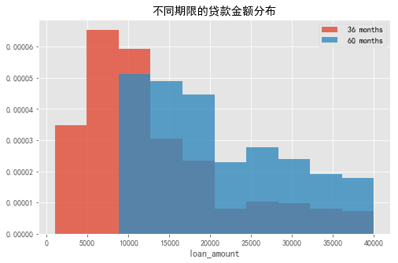

```python
loan.groupby('term').apply(lambda x:x.loan_amnt).unstack().T.plot.hist(alpha=0.8,normed=1,figsize=(8,5))
plt.title('不同期限的贷款金额分布')
plt.ylabel('')
plt.xlabel('loan_amount')
plt.legend()
plt.show()
```

- 5年期贷款最低申请金额为1万美元，低于1万美元的个人贷款只能申请3年的期限；
- 5年期贷款的整体额度水平高于3年期贷款，贷款金额超过2万美元的占比达到50%。

```python
grade_percentage = (loan.grade.value_counts()/len(loan)).sort_index().reset_index()
grade_percentage.columns = ['grade','percentage']
grade_percentage
```

|  | grade | percentage |
| --- | --- | --- |
| 0 | A | 0.258219 |
| 1 | B | 0.298363 |
| 2 | C | 0.268297 |
| 3 | D | 0.138528 |
| 4 | E | 0.030516 |
| 5 | F | 0.005308 |
| 6 | G | 0.000769 |

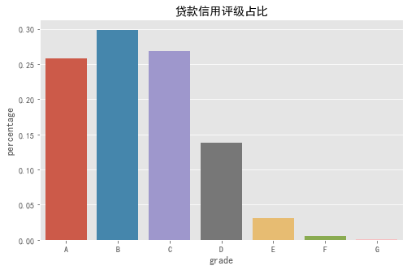

```python
plt.figure(figsize=(8,5))
sns.barplot(x='grade',y='percentage',data=grade_percentage)
plt.title('贷款信用评级占比')
plt.show()
```

- 平台个人贷款业务的贷款信用评级分为A、B、C、D、E、F、G七个等级，信用最高级别为A级，最低级别为G级；
- B级贷款占比最高，其次为C级和A级贷款，A、B、C、D四个等级贷款的总占比为96%，E、F、G等级贷款的占比较小；
- 为了加强信用风险管理，平台对贷款信用评级要求较高。

```python
loan.describe()[['int_rate']].T
```

|  | count | mean | std | min | 25% | 50% | 75% | max |
| --- | --- | --- | --- | --- | --- | --- | --- | --- |
| int_rate | 204218.0 | 12.353199 | 4.952125 | 5.31 | 8.08 | 11.98 | 15.05 | 30.99 |

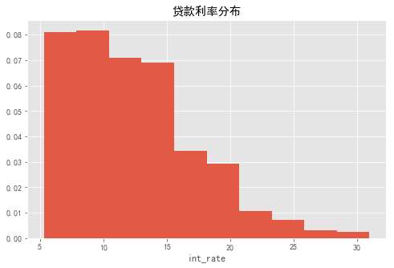

```python
plt.figure(figsize=(8,5))
plt.hist(loan.int_rate,bins=10,alpha=0.9,normed=1)
plt.title('贷款利率分布')
plt.xlabel('int_rate')
plt.show()
```

- 平台个人贷款业务的贷款利率在5.31%-30.99%之间；
- 贷款利率整体呈右偏分布，集中于较低的利率水平，中位数为11.98%，利率水平在5%-15%之间的占比约为75%；
- 信用风险会影响贷款利率水平，信用风险越大，贷款利率水平越高，平台更偏向于低风险的低利率水平。

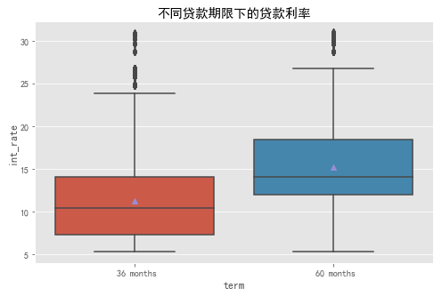

```python
plt.figure(figsize=(8,5))
sns.boxplot(x='term',y='int_rate',data=loan,showmeans=True)
plt.title('不同贷款期限下的贷款利率')
plt.show()
```

- 5年期贷款的信用风险高于3年期贷款，5年期贷款的整体利率水平亦高于3年期贷款。

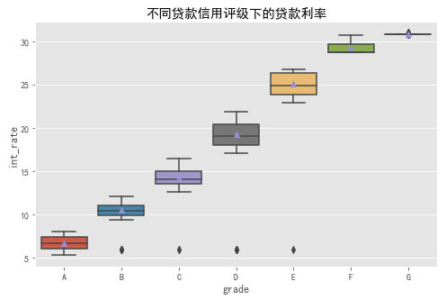

```python
plt.figure(figsize=(8,5))
sns.boxplot(x='grade',y='int_rate',data=loan,order=['A','B','C','D','E','F','G'],showmeans=True)
plt.title('不同贷款信用评级下的贷款利率')
plt.show()
```

- 贷款信用评级A-G级的信用风险依次增大，贷款利率水平也依次升高，G级贷款的利率最高。

```python
(loan.loan_status.value_counts()/len(loan)).reset_index()
```

|  | index | loan_status |
| --- | --- | --- |
| 0 | Current | 0.927171 |
| 1 | Fully Paid | 0.052175 |
| 2 | In Grace Period | 0.007776 |
| 3 | Late (31-120 days) | 0.007419 |
| 4 | Late (16-30 days) | 0.003041 |
| 5 | Charged Off | 0.002419 |

- 平台将贷款状态分为六种：
  - Current：执行还款中
  - Fully Paid：正常结清
  - In Grace Period：宽限期
  - Late (16-30 days)：逾期16-30天
  - Late (31-120 days)：逾期31-120天
  - Charged Off：坏账冲销
- 探索分析中将贷款状态转换为两大类，正常和问题贷款，问题贷款为违约贷款：
  - 正常贷款：Current、Fully Paid
  - 问题贷款：In Grace Period、Late (16-30 days)、Late (31-120 days)、Charged Off

```python
loan['loan_status_trans'] = loan.loan_status
loan_status_trans = {
    'loan_status_trans':{
        'Current':'正常贷款',
        'Fully Paid':'正常贷款',
        'In Grace Period':'问题贷款',
        'Late (16-30 days)':'问题贷款',
        'Late (31-120 days)':'问题贷款',
        'Charged Off':'问题贷款'
    }
}
loan.replace(loan_status_trans,inplace=True)
```

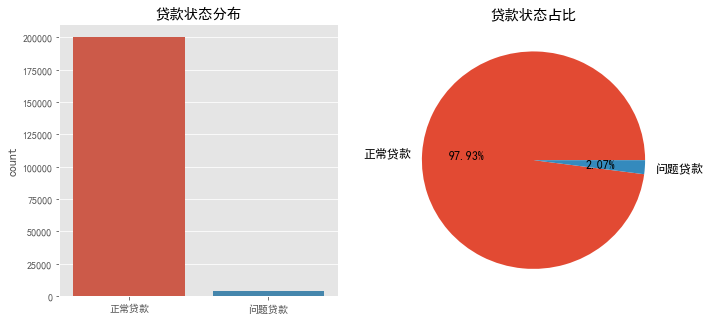

```python
plt.figure(figsize=(11,5))
plt.subplot(121)
sns.countplot(x='loan_status_trans',data=loan)
plt.xlabel('')
plt.title('贷款状态分布')

plt.subplot(122)
(loan.loan_status_trans.value_counts()/len(loan)).plot.pie(autopct='%1.2f%%',fontsize=12)
plt.ylabel('')
plt.title('贷款状态占比')
plt.show()
```

- 个人贷款业务中，正常贷款占比97.93%，问题贷款占比2.07%，平台信贷风险管理严格，对违约贷款的把控效果良好。

#### 3.1.3 平台个人贷款业务总结

- 综合以上分析，LendingClub平台个人贷款业务规模和业务特点如下：
  - 业务规模整体呈增长趋势，受季节性因素影响，有一定的波动性；
  - 属于小额贷款服务；
  - 贷款利率综合考虑信用风险因素，实行差异化策略，贷款信用评级高、期限短的贷款利率低；
  - 贷款违约风险得到良好的控制。

### 3.2 平台贷款客户特征分析

#### 3.2.1 平台贷款客户基本情况分析

- 从地域分布、职业分布、工作年限、年收入分布、债务收入比、房屋所有权状况、收入认证状态七个维度展开分析。

```python
addr_state = (loan.addr_state.value_counts()/len(loan)).head(10).reset_index()
addr_state.columns = ['addr_state','percentage']
addr_state
```

|  | addr_state | percentage |
| --- | --- | --- |
| 0 | CA | 0.136991 |
| 1 | NY | 0.083132 |
| 2 | TX | 0.081976 |
| 3 | FL | 0.076007 |
| 4 | IL | 0.039468 |
| 5 | NJ | 0.035839 |
| 6 | GA | 0.034125 |
| 7 | OH | 0.031721 |
| 8 | PA | 0.031628 |
| 9 | NC | 0.028641 |

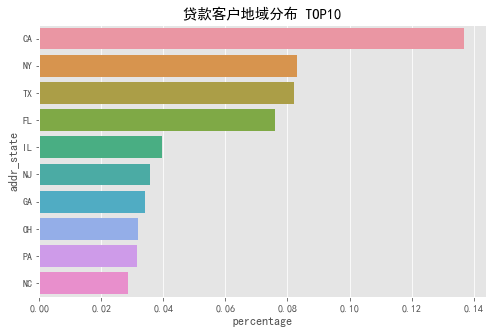

```python
plt.figure(figsize=(8,5))
sns.barplot(y='addr_state',x='percentage',data=addr_state)
plt.title('贷款客户地域分布 TOP10')
plt.show()
```

- 平台贷款客户遍及美国50个州，加利福尼亚州占比最高，约为13.7%，平台总部地区市场规模较大，其次为纽约州、得克萨斯州、佛罗里达州，排名前十的州总占比为58%，市场相对集中在经济发达州。

```python
emp_title = (loan.emp_title.value_counts()/len(loan)).head(10).reset_index()
emp_title.columns = ['occupation','percentage']
emp_title
```

|  | occupation | percentage |
| --- | --- | --- |
| 0 | unknown | 0.074930 |
| 1 | Manager | 0.017805 |
| 2 | Owner | 0.016664 |
| 3 | Teacher | 0.015645 |
| 4 | Driver | 0.009838 |
| 5 | Registered Nurse | 0.007267 |
| 6 | Sales | 0.006880 |
| 7 | Supervisor | 0.006527 |
| 8 | RN | 0.006287 |
| 9 | Project Manager | 0.005009 |

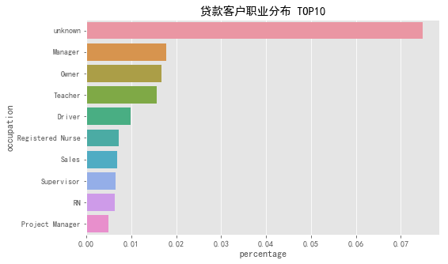

```python
plt.figure(figsize=(8,5))
sns.barplot(y='occupation',x='percentage',data=emp_title)
plt.title('贷款客户职业分布 TOP10')
plt.show()
```

- 平台贷款客户的职业分布十分广泛，有超过6万种不同职称，绝大部分客户有固定职业，即有稳定的收入来源；
- 不愿意透露个人职业情况的客户占比7.5%，平台需进一步确认其收入来源。

```python
emp_length = (loan.emp_length.value_counts()/len(loan)).reset_index()
emp_length.columns = ['emp_length','percentage']
emp_length
```

|  | emp_length | percentage |
| --- | --- | --- |
| 0 | 10+ years | 0.333609 |
| 1 | 2 years | 0.095476 |
| 2 | 3 years | 0.085110 |
| 3 | n/a | 0.073265 |
| 4 | < 1 year | 0.069010 |
| 5 | 1 year | 0.067815 |
| 6 | 4 years | 0.066414 |
| 7 | 5 years | 0.063638 |
| 8 | 6 years | 0.046392 |
| 9 | 7 years | 0.038165 |
| 10 | 8 years | 0.032255 |
| 11 | 9 years | 0.028852 |

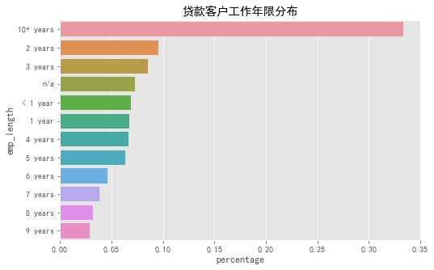

```python
plt.figure(figsize=(8,5))
sns.barplot(y='emp_length',x='percentage',data=emp_length)
plt.title('贷款客户工作年限分布')
plt.show()
```

- 平台贷款客户的工作年限主要集中在十年以上，占比33.4%，客户普遍具有一定的工作资历，不愿意透露工作年限的客户占比7.3%。

```python
loan.describe()[['annual_inc']].T
```

|  | count | mean | std | min | 25% | 50% | 75% | max |
| --- | --- | --- | --- | --- | --- | --- | --- | --- |
| annual_inc | 204218.0 | 81647.30976 | 85463.21311 | 1900.0 | 48000.0 | 68000.0 | 98000.0 | 9930475.0 |

- 平台贷款客户的平均年收入为8.16万美元，中位数为6.8万美元，超过75%的客户年收入在10万美元以内，最低年收入为1900美元，最高竟高达993万美元，标准差为8.55万美元，波动非常大，存在极大的异常值。

```python
bins = [0,25000,50000,75000,100000,200000,300000,10000000]
loan['annual_inc_bins'] = pd.cut(loan.annual_inc,bins=bins)
annual_inc_bins = (loan['annual_inc_bins'].value_counts().sort_index()/len(loan)).reset_index()
annual_inc_bins.columns = ['annual_inc_bins','percentage']
```

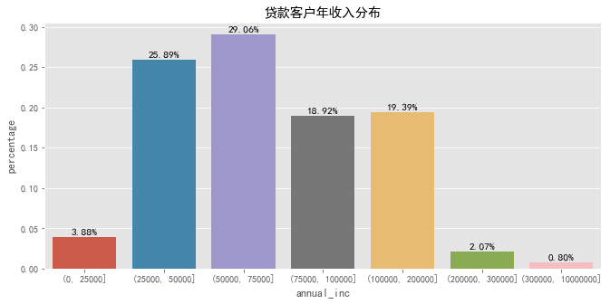

```python
plt.figure(figsize=(11,5))
sns.barplot(x='annual_inc_bins',y='percentage',data=annual_inc_bins)
plt.title('贷款客户年收入分布')
plt.xlabel('annual_inc')
for x,y in zip([i for i in range(0,7)],annual_inc_bins.percentage):
    plt.text(x,y+0.003,'%.2f%%'%(y*100),ha='center',fontsize=11.5)
plt.show()
```

- 根据贷款客户年收入分布图显示，年收入不超过2.5万美元的占比3.88%，低收入客户较少；
- 贷款客户年收入主要集中在2.5-5万美元、5-7.5万美元之间，占比分别为25.89%、29.06%；
- 年收入在7.5-30万美元之间的高收入客户总占比约为40%，平台贷款客户整体收入状况良好；
- 99.2%的客户年收入不超过30万美元，少数客户年收入极高，后续关于年收入的分析会排除极大值的干扰。
- 进一步探索工作年限和年收入的关系，将工作年限转换成数字类型，不愿意透露的记作0，工作年限小于1年的记作1，大于1年的记作2，大于2年的记作3，以此类推。

```python
loan['emp_length_trans'] = loan['emp_length']
emp_length_trans = {
    'emp_length_trans':{
        'n/a':0,'< 1 year':1,'1 year':2,'2 years':3,'3 years':4,'4 years':5,'5 years':6,'6 years':7,'7 years':8,'8 years':9,'9 years':10,
        '10+ years':11 }
}
loan.replace(emp_length_trans,inplace=True)
```

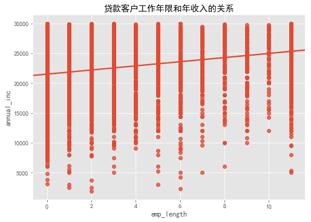

```python
sns.lmplot(x='emp_length_trans',y='annual_inc',data=loan.query('annual_inc < 30000'),aspect=1.45)
plt.title('贷款客户工作年限和年收入的关系')
plt.xlabel('emp_length')
plt.show()
```

- 由工作年限和年收入的关系图可知，工作年限越长，年收入往高收入集中的趋势越明显，一般来说，同一职业，资历越深的年收入越高，对不愿意透露工作年限的客户需进一步确认其收入情况。

```python
loan.describe()[['dti']].T
```

|  | count | mean | std | min | 25% | 50% | 75% | max |
| --- | --- | --- | --- | --- | --- | --- | --- | --- |
| dti | 204218.0 | 17.399358 | 8.7613 | 0.0 | 10.79 | 16.8 | 23.49 | 39.99 |

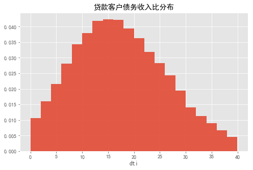

```python
loan.dti.hist(bins=20,alpha=0.9,normed=1,figsize=(8,5))
plt.title('贷款客户债务收入比分布')
plt.xlabel('dti')
plt.show()
```

- 平台贷款客户债务收入比低于40%；
- 贷款客户债务收入比分布稍向右偏，大致呈钟形分布，中位数为16.8%；
- 债务收入比越高，客户还款压力越大，信用风险越高，平台更偏向于低债务风险的客户。

```python
home_ownership = (loan.home_ownership.value_counts()/len(loan)).reset_index()
home_ownership.columns = ['home_ownership','percentage']
home_ownership
```

|  | home_ownership | percentage |
| --- | --- | --- |
| 0 | MORTGAGE | 0.447634 |
| 1 | RENT | 0.419439 |
| 2 | OWN | 0.132838 |
| 3 | ANY | 0.000088 |

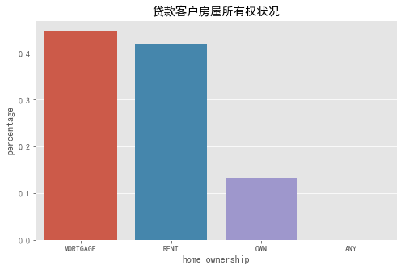

```python
plt.figure(figsize=(8,5))
sns.barplot(x='home_ownership',y='percentage',data=home_ownership)
plt.title('贷款客户房屋所有权状况')
plt.show()
```

- 平台贷款客户的房屋所有权状况主要是抵押状态，占比44.8%，租住房屋的客户占比42%；
- 13%的客户拥有房屋所有权，个别客户房屋所有权状况不明，平台需进一步确认其资产情况。

```python
verification = (loan.verification_status.value_counts()/len(loan)).sort_index(ascending=False).reset_index()
verification.columns = ['verification_status','percentage']
verification
```

|  | verification_status | percentage |
| --- | --- | --- |
| 0 | Verified | 0.205192 |
| 1 | Source Verified | 0.416702 |
| 2 | Not Verified | 0.378106 |

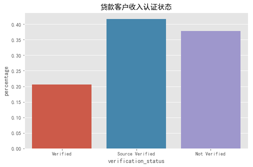

```python
plt.figure(figsize=(8,5))
sns.barplot(x='verification_status',y='percentage',data=verification)
plt.title('贷款客户收入认证状态')
plt.show()
```

- 平台主要对申请信息不完整或存在其他可疑情况的贷款客户进行收入认证，收入认证状态分为三种：收入认证、收入来源认证、未认证；
- 经过收入认证、收入来源认证的贷款客户总占比62.2%，未经过认证的占比37.8%。

#### 3.2.2 平台贷款客户行为状况分析

- 从贷款原因、征信查询次数、欠款账户数量、逾期违约次数、贷款坏账冲销次数五个维度展开分析。

```python
loan_purpose = (loan.title.value_counts()/len(loan)).reset_index()
loan_purpose.columns = ['loan_purpose','percentage']
loan_purpose
```

|  | loan_purpose | percentage |
| --- | --- | --- |
| 0 | Debt consolidation | 0.488782 |
| 1 | Credit card refinancing | 0.249087 |
| 2 | Other | 0.091407 |
| 3 | Home improvement | 0.069367 |
| 4 | Major purchase | 0.030257 |
| 5 | Home buying | 0.017770 |
| 6 | Medical expenses | 0.014631 |
| 7 | Car financing | 0.012374 |
| 8 | Business | 0.010949 |
| 9 | Vacation | 0.007947 |
| 10 | Moving and relocation | 0.006860 |
| 11 | Green loan | 0.000568 |

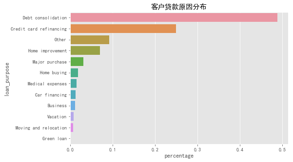

```python
plt.figure(figsize=(8,5))
sns.barplot(y='loan_purpose',x='percentage',data=loan_purpose)
plt.title('客户贷款原因分布')
plt.show()
```

- 客户贷款原因包括债务合并、信用卡还款、购买房屋、住房改善、商业用途等，其中主要贷款原因是债务合并，占比高达48.9%，平台接近一半的客户贷款用于偿还其他债务，25%的客户用于信用卡还款，客户财务风险越大，平台承担的违约风险越大。

```python
inq_last_6mths = (loan.inq_last_6mths.value_counts()/len(loan)).reset_index()
inq_last_6mths.columns = ['inq_last_6mths','percentage']
inq_last_6mths
```

|  | inq_last_6mths | percentage |
| --- | --- | --- |
| 0 | 0 | 0.656999 |
| 1 | 1 | 0.243514 |
| 2 | 2 | 0.075512 |
| 3 | 3 | 0.022726 |
| 4 | 4 | 0.000921 |
| 5 | 5 | 0.000328 |

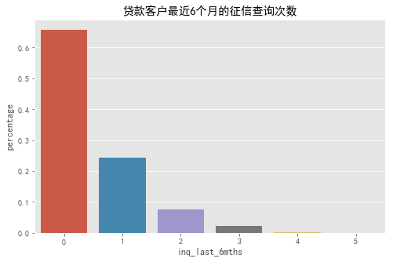

```python
plt.figure(figsize=(8,5))
sns.barplot(x='inq_last_6mths',y='percentage',data=inq_last_6mths)
plt.title('贷款客户最近6个月的征信查询次数')
plt.show()
```

- 平台贷款客户最近6个月的征信查询次数不超过5次；
- 65.7%的客户最近6个月的征信查询次数为0次，1次的占比24.4%，99.88%的客户征信查询次数不超过3次；
- 绝大部分客户的资金状况良好，少数客户存在频繁查询征信记录的情况。

```python
acc_now_delinq = (loan.acc_now_delinq.value_counts()/len(loan)).reset_index()
acc_now_delinq.columns = ['acc_now_delinq','percentage']
acc_now_delinq
```

|  | acc_now_delinq | percentage |
| --- | --- | --- |
| 0 | 0 | 0.999873 |
| 1 | 1 | 0.000127 |

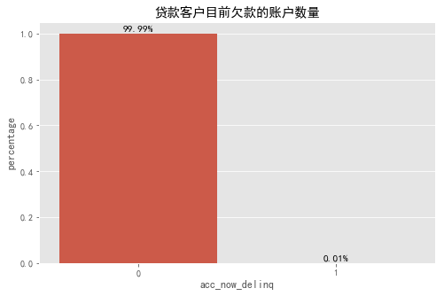

```python
plt.figure(figsize=(8,5))
sns.barplot(x='acc_now_delinq',y='percentage',data=acc_now_delinq)
for x,y in zip([0,1],acc_now_delinq.percentage):
    plt.text(x,y+0.01,'%.2f%%'%(y*100),ha='center',fontsize=11.5)
plt.title('贷款客户目前欠款的账户数量')
plt.show()
```

- 平台贷款客户目前欠款的账户数量大都为0个，整体资金状况正常；
- 个别客户有1个账户欠款，资金风险较大。

```python
delinq_2yrs = (loan.delinq_2yrs.value_counts()/len(loan)).reset_index()
delinq_2yrs.columns = ['delinq_2yrs','percentage']
delinq_2yrs.head(4)
```

|  | delinq_2yrs | percentage |
| --- | --- | --- |
| 0 | 0 | 0.853201 |
| 1 | 1 | 0.102954 |
| 2 | 2 | 0.025688 |
| 3 | 3 | 0.009250 |

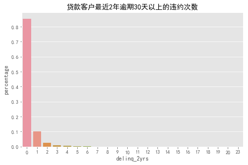

```python
plt.figure(figsize=(8,5))
sns.barplot(x='delinq_2yrs',y='percentage',data=delinq_2yrs)
plt.title('贷款客户最近2年逾期30天以上的违约次数')
plt.show()
```

- 最近2年逾期30天以上的违约次数为0次的贷款客户占比85.32%，99.1%的客户违约次数不超过3次，绝大部分客户的信用记录良好；
- 部分客户存在频繁违约的情况，信用风险较大。

```python
chargeoff_within_12_mths = (loan.chargeoff_within_12_mths.value_counts()/len(loan)).reset_index()
chargeoff_within_12_mths.columns = ['chargeoff_within_12_mths','percentage']
chargeoff_within_12_mths
```

|  | chargeoff_within_12_mths | percentage |
| --- | --- | --- |
| 0 | 0 | 0.993497 |
| 1 | 1 | 0.006038 |
| 2 | 2 | 0.000362 |
| 3 | 3 | 0.000059 |
| 4 | 4 | 0.000029 |
| 5 | 9 | 0.000005 |
| 6 | 7 | 0.000005 |
| 7 | 6 | 0.000005 |

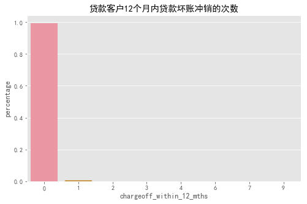

```python
plt.figure(figsize=(8,5))
sns.barplot(x='chargeoff_within_12_mths',y='percentage',data=chargeoff_within_12_mths)
plt.title('贷款客户12个月内贷款坏账冲销的次数')
plt.show()
```

- 12个月内贷款坏账冲销的次数为0次的贷款客户占比99.35%，1次的占比0.6%，客户的信用状况普遍较好；
- 少数客户贷款坏账冲销的次数超过1次，贷款坏账冲销的次数越多，信用风险越大。

#### 3.2.3 平台贷款客户特征总结

- 综合以上分析，平台贷款客户特征如下：
  - 客户主要来自美国经济发达州，有稳定的职业和一定的工作资历，整体收入状况良好，债务收入比比较低；
  - 贷款原因主要是债务合并和信用卡还款，客户还款压力较大；
  - 客户整体资金状况良好，大部分不存在欠款账户和频繁查询征信记录的情况；
  - 客户整体信用记录良好，大部分不存在违约事项。

### 3.3 贷款违约影响因素分析

#### 3.3.1 贷款金额、期限、利率、信用评级与违约贷款的关系

```python
bins = [0,10000,20000,30000,40000]
loan['loan_amnt_bins'] = pd.cut(loan.loan_amnt,bins=bins)
```

```python
loan_amnt_status = loan.pivot_table(index='loan_amnt_bins',columns='loan_status_trans',
                                         values='loan_status',aggfunc='count').apply(lambda x:x/x.sum(),axis=1).reset_index()
loan_amnt_status['total'] = loan_amnt_status['正常贷款'] + loan_amnt_status['问题贷款']
loan_amnt_status
```

| loan_status_trans | loan_amnt_bins | 正常贷款 | 问题贷款 | total |
| --- | --- | --- | --- | --- |
| 0 | (0, 10000] | 0.981742 | 0.018258 | 1.0 |
| 1 | (10000, 20000] | 0.980358 | 0.019642 | 1.0 |
| 2 | (20000, 30000] | 0.974732 | 0.025268 | 1.0 |
| 3 | (30000, 40000] | 0.972472 | 0.027528 | 1.0 |

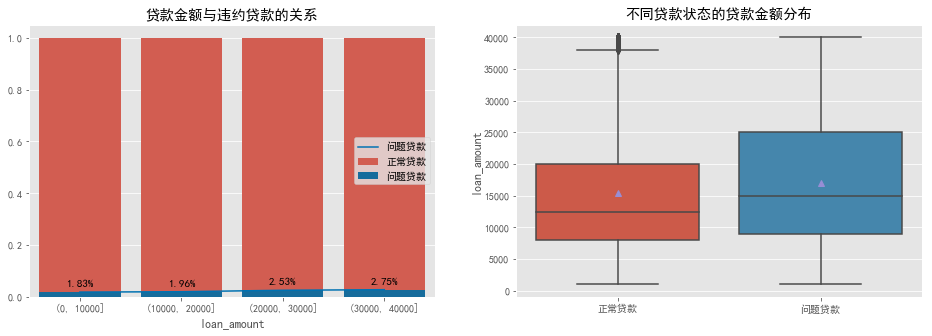

```python
plt.figure(figsize=(16,5))
plt.subplot(121)
sns.barplot(x='loan_amnt_bins',y='total',data=loan_amnt_status,color='#e74c3c',label='正常贷款')
sns.barplot(x='loan_amnt_bins',y='问题贷款',data=loan_amnt_status,color='#0072B2',label='问题贷款')
plt.twinx
plt.plot(loan_amnt_status.index,loan_amnt_status['问题贷款'],c='#0072B2')
for x,y in zip(loan_amnt_status.index,loan_amnt_status['问题贷款']):
    plt.text(x,y+0.02,'%.2f%%' % (y*100),ha='center',fontsize=11)
plt.ylabel('')
plt.xlabel('loan_amount')
plt.legend(loc=7)
plt.title('贷款金额与违约贷款的关系')

plt.subplot(122)
sns.boxplot(x='loan_status_trans',y='loan_amnt',data=loan,showmeans=True)
plt.title('不同贷款状态的贷款金额分布')
plt.ylabel('loan_amount')
plt.xlabel('')
plt.show()
```

- 贷款金额越高，贷款违约的风险越大，违约率呈轻微上升趋势；
- 违约贷款的整体额度水平高于正常贷款。

```python
term_status = loan.pivot_table(index='term',columns='loan_status_trans',
                                         values='loan_status',aggfunc='count').apply(lambda x:x/x.sum(),axis=1)
term_status['total'] = term_status['正常贷款'] + term_status['问题贷款']
term_status
```

| loan_status_trans term | 正常贷款 | 问题贷款 | total |
| --- | --- | --- | --- |
| 36 months | 0.981738 | 0.018262 | 1.0 |
| 60 months | 0.973219 | 0.026781 | 1.0 |

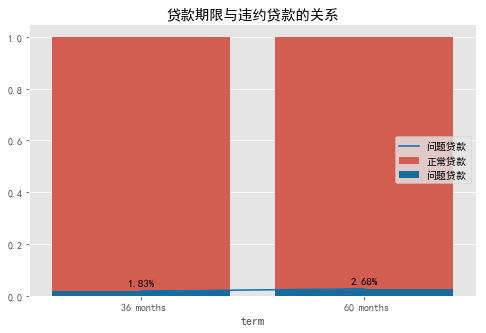

```python
plt.figure(figsize=(8,5))
sns.barplot(x=term_status.index,y='total',data=term_status,color='#e74c3c',label='正常贷款')
sns.barplot(x=term_status.index,y='问题贷款',data=term_status,color='#0072B2',label='问题贷款')
plt.twinx
plt.plot(term_status.index,term_status['问题贷款'],c='#0072B2')
for x,y in zip(term_status.index,term_status['问题贷款']):
    plt.text(x,y+0.02,'%.2f%%' % (y*100),ha='center',fontsize=11)
plt.ylabel('')
plt.legend(loc=7)
plt.title('贷款期限与违约贷款的关系')
plt.show()
```

- 贷款期限越长，贷款违约的风险越大，5年期贷款的违约率高于3年期贷款。

```python
bins = [5,10,15,20,25,30,35]
loan['int_rate_bins'] = pd.cut(loan.int_rate,bins=bins)
int_rate_status = loan.pivot_table(index='int_rate_bins',columns='loan_status_trans',
                                         values='loan_status',aggfunc='count').apply(lambda x:x/x.sum(),axis=1).reset_index()
int_rate_status['total'] = int_rate_status['正常贷款'] + int_rate_status['问题贷款']
int_rate_status
```

| loan_status_trans | int_rate_bins | 正常贷款 | 问题贷款 | total |
| --- | --- | --- | --- | --- |
| 0 | (5, 10] | 0.991908 | 0.008092 | 1.0 |
| 1 | (10, 15] | 0.981405 | 0.018595 | 1.0 |
| 2 | (15, 20] | 0.965432 | 0.034568 | 1.0 |
| 3 | (20, 25] | 0.952044 | 0.047956 | 1.0 |
| 4 | (25, 30] | 0.932023 | 0.067977 | 1.0 |
| 5 | (30, 35] | 0.915865 | 0.084135 | 1.0 |

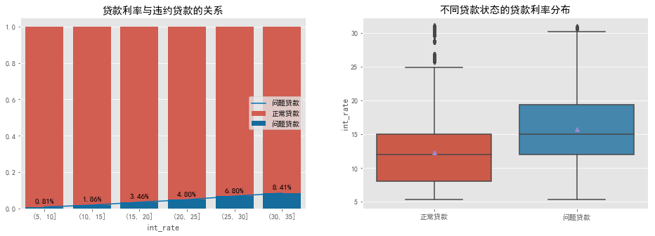

```python
plt.figure(figsize=(16,5))
plt.subplot(121)
sns.barplot(x='int_rate_bins',y='total',data=int_rate_status,color='#e74c3c',label='正常贷款')
sns.barplot(x='int_rate_bins',y='问题贷款',data=int_rate_status,color='#0072B2',label='问题贷款')
plt.twinx
plt.plot(int_rate_status.index,int_rate_status['问题贷款'],c='#0072B2')
for x,y in zip(int_rate_status.index,int_rate_status['问题贷款']):
    plt.text(x,y+0.02,'%.2f%%' % (y*100),ha='center',fontsize=11)
plt.ylabel('')
plt.xlabel('int_rate')
plt.legend(loc=7)
plt.title('贷款利率与违约贷款的关系')

plt.subplot(122)
sns.boxplot(x='loan_status_trans',y='int_rate',data=loan,showmeans=True)
plt.legend()
plt.title('不同贷款状态的贷款利率分布')
plt.xlabel('')
plt.show()
```

- 贷款利率越高，客户借贷成本越高，贷款违约的风险越大，违约率的上升趋势显著，利率超过30%的贷款违约率高达8.41%；
- 违约贷款的整体利率水平高于正常贷款。

```python
grade_status=loan.pivot_table(index='grade',columns='loan_status_trans',aggfunc='count',values='loan_status').apply(lambda x:x/x.sum(),axis=1)
grade_status['total'] = grade_status['正常贷款'] + grade_status['问题贷款']
grade_status
```

| loan_status_trans grade | 正常贷款 | 问题贷款 | total |
| --- | --- | --- | --- |
| A | 0.993856 | 0.006144 | 1.0 |
| B | 0.985278 | 0.014722 | 1.0 |
| C | 0.975416 | 0.024584 | 1.0 |
| D | 0.958572 | 0.041428 | 1.0 |
| E | 0.940308 | 0.059692 | 1.0 |
| F | 0.915129 | 0.084871 | 1.0 |
| G | 0.910828 | 0.089172 | 1.0 |

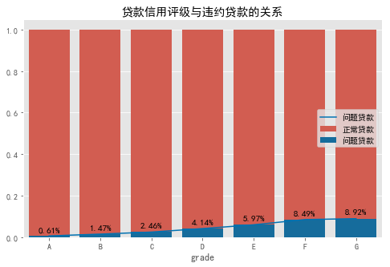

```python
plt.figure(figsize=(8,5))
sns.barplot(x=grade_status.index,y='total',data=grade_status,color='#e74c3c',label='正常贷款')
sns.barplot(x=grade_status.index,y='问题贷款',data=grade_status,color='#0072B2',label='问题贷款')
plt.twinx
plt.plot(grade_status.index,grade_status['问题贷款'],c='#0072B2')
for x,y in zip(grade_status.index,grade_status['问题贷款']):
    plt.text(x,y+0.02,'%.2f%%' % (y*100),ha='center',fontsize=11)
plt.ylabel('')
plt.legend(loc=7)
plt.title('贷款信用评级与违约贷款的关系')
plt.show()
```

- 贷款信用评级等级越低，信用风险越高，贷款违约的风险越大，违约率的上升趋势显著，F级和G级贷款违约率均超过8%，分别为8.49%、8.92%。

#### 3.3.2 客户收入状况与违约贷款的关系

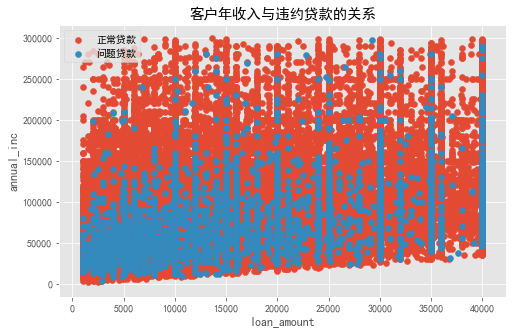

```python
plt.figure(figsize=(8,5))
plt.title('客户年收入与违约贷款的关系')
plt.xlabel('loan_amount')
plt.ylabel('annual_inc')
for status,grouped in loan.query('annual_inc < 300000').groupby('loan_status_trans'):
    x = grouped.loan_amnt
    y = grouped.annual_inc
    plt.scatter(x,y,label=status)
    plt.legend(loc=2)
```

- 由客户年收入与违约贷款的关系图可知，违约贷款的客户年收入主要集中在10万美元以下；
- 当贷款金额一定时，违约贷款的客户年收入往低收入水平的集中趋势明显，年收入越低，客户还款能力越弱，贷款违约的风险越大；
- 为了加强风险管理，不同贷款额度的最低年收入要求不同，贷款额度越高，平台要求的年收入标准越高。

```python
loan['monthly_disposable_income'] = (loan['annual_inc']/12)  * (1 - loan['dti'] / 100)
```

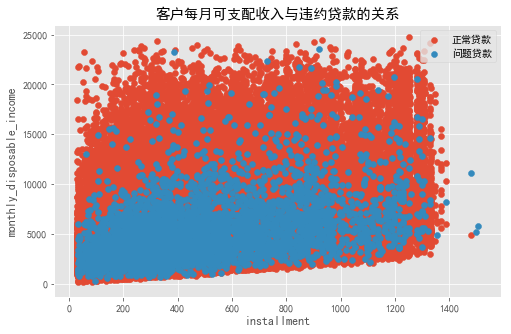

```python
plt.figure(figsize=(8,5))
plt.title('客户每月可支配收入与违约贷款的关系')
plt.ylabel('monthly_disposable_income')
plt.xlabel('installment')
for status,grouped in loan.query('annual_inc < 300000').groupby('loan_status_trans'):
    x = grouped.installment
    y = grouped.monthly_disposable_income
    plt.scatter(x,y,label=status)
    plt.legend(loc=1)
```

- monthly_disposable_income：客户每月可支配收入，通过年收入和债务收入比两个变量计算得出；
- 由客户每月可支配收入与违约贷款的关系图可知，违约贷款的客户每月可支配收入主要集中在1万美元以下；
- 当每月还款金额一定时，违约贷款的客户每月可支配收入往低收入水平的集中趋势明显，每月可支配收入越低，客户还款压力越大，贷款违约的风险越大。

```python
verification_status = loan.pivot_table(index='verification_status',columns='loan_status_trans',
                                         values='loan_status',aggfunc='count').apply(lambda x:x/x.sum(),axis=1).reset_index()
verification_status['total'] = verification_status['正常贷款'] + verification_status['问题贷款']
verification_status
```

| loan_status_trans | verification_status | 正常贷款 | 问题贷款 | total |
| --- | --- | --- | --- | --- |
| 0 | Not Verified | 0.985586 | 0.014414 | 1.0 |
| 1 | Source Verified | 0.979353 | 0.020647 | 1.0 |
| 2 | Verified | 0.967831 | 0.032169 | 1.0 |

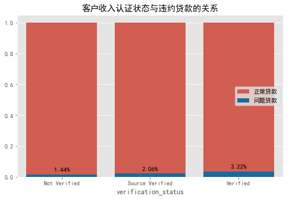

```python
plt.figure(figsize=(8,5))
sns.barplot(x='verification_status',y='total',data=verification_status,color='#e74c3c',label='正常贷款')
sns.barplot(x='verification_status',y='问题贷款',data=verification_status,color='#0072B2',label='问题贷款')
for x,y in zip(verification_status.index,verification_status['问题贷款']):
    plt.text(x,y+0.02,'%.2f%%' % (y*100),ha='center',fontsize=11)
plt.ylabel('')
plt.legend(loc=7)
plt.title('客户收入认证状态与违约贷款的关系')
plt.show()
```

- 不同客户收入认证状态的违约率如上图所示，平台主要对可疑客户进行收入认证，经过认证的违约率比未认证的高。

#### 3.3.3 客户工作年限、房屋所有权状况与违约贷款的关系

```python
emp_length_status = loan.pivot_table(index='emp_length',columns='loan_status_trans',values='loan_status',
                    aggfunc='count').apply(lambda x:x/x.sum(),axis=1).sort_values('问题贷款',ascending=False).reset_index()
emp_length_status['total'] = emp_length_status['正常贷款'] + emp_length_status['问题贷款']
emp_length_status
```

| loan_status_trans | emp_length | 正常贷款 | 问题贷款 | total |
| --- | --- | --- | --- | --- |
| 0 | n/a | 0.973867 | 0.026133 | 1.0 |
| 1 | 1 year | 0.976894 | 0.023106 | 1.0 |
| 2 | 3 years | 0.977677 | 0.022323 | 1.0 |
| 3 | 8 years | 0.977683 | 0.022317 | 1.0 |
| 4 | 2 years | 0.977895 | 0.022105 | 1.0 |
| 5 | 4 years | 0.977955 | 0.022045 | 1.0 |
| 6 | 5 years | 0.978686 | 0.021314 | 1.0 |
| 7 | 7 years | 0.979215 | 0.020785 | 1.0 |
| 8 | < 1 year | 0.979848 | 0.020152 | 1.0 |
| 9 | 9 years | 0.981331 | 0.018669 | 1.0 |
| 10 | 10+ years | 0.981814 | 0.018186 | 1.0 |
| 11 | 6 years | 0.982056 | 0.017944 | 1.0 |

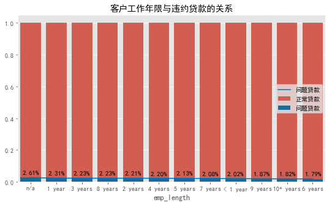

```python
plt.figure(figsize=(9,5))
sns.barplot(x='emp_length',y='total',data=emp_length_status,color='#e74c3c',label='正常贷款')
sns.barplot(x='emp_length',y='问题贷款',data=emp_length_status,color='#0072B2',label='问题贷款')
plt.twinx
plt.plot(emp_length_status.index,emp_length_status['问题贷款'],c='#0072B2')
for x,y in zip(emp_length_status.index,emp_length_status['问题贷款']):
    plt.text(x,y+0.02,'%.2f%%' % (y*100),ha='center',fontsize=11)
plt.ylabel('')
plt.legend(loc=7)
plt.title('客户工作年限与违约贷款的关系')
plt.show()
```

- 根据客户工作年限与违约贷款的关系图显示，不同工作年限的贷款客户违约率相差不大，工作年限超过十年的违约率较低，为1.82%；
- 不愿意透露工作年限的客户违约率最高，违约率为2.61%，贷款违约的风险较大。

```python
home_ownership_status = loan.pivot_table(index='home_ownership',columns='loan_status_trans',values='loan_status',
                    aggfunc='count').apply(lambda x:x/x.sum(),axis=1).sort_values('问题贷款',ascending=False).reset_index()
home_ownership_status['total'] = home_ownership_status['正常贷款'] + home_ownership_status['问题贷款']
home_ownership_status
```

| loan_status_trans | home_ownership | 正常贷款 | 问题贷款 | total |
| --- | --- | --- | --- | --- |
| 0 | ANY | 0.944444 | 0.055556 | 1.0 |
| 1 | RENT | 0.976161 | 0.023839 | 1.0 |
| 2 | OWN | 0.977698 | 0.022302 | 1.0 |
| 3 | MORTGAGE | 0.982826 | 0.017174 | 1.0 |

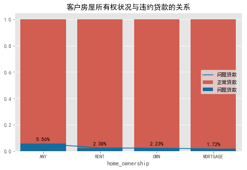

```python
plt.figure(figsize=(8,5))
sns.barplot(x='home_ownership',y='total',data=home_ownership_status,color='#e74c3c',label='正常贷款')
sns.barplot(x='home_ownership',y='问题贷款',data=home_ownership_status,color='#0072B2',label='问题贷款')
plt.twinx
plt.plot(home_ownership_status.index,home_ownership_status['问题贷款'],c='#0072B2')
for x,y in zip(home_ownership_status.index,home_ownership_status['问题贷款']):
    plt.text(x,y+0.02,'%.2f%%' % (y*100),ha='center',fontsize=11)
plt.ylabel('')
plt.legend(loc=7)
plt.title('客户房屋所有权状况与违约贷款的关系')
plt.show()
```

- 根据客户房屋所有权状况与违约贷款的关系图显示，不愿意透露房屋所有权状况的客户违约率最高，达到5.56%，贷款违约的风险较大；
- 租住房屋的客户违约率为2.38%，租金支出加重客户还款压力；
- 自有、抵押房屋的客户违约率分别为2.23%、1.72%。

#### 3.3.4 客户资金状况与违约贷款的关系

```python
inq_last_6mths_status = loan.pivot_table(index='inq_last_6mths',columns='loan_status_trans',values='loan_status',
                    aggfunc='count').apply(lambda x:x/x.sum(),axis=1)
inq_last_6mths_status['total'] = inq_last_6mths_status['正常贷款'] + inq_last_6mths_status['问题贷款']
inq_last_6mths_status
```

| loan_status_trans inq_last_6mths | 正常贷款 | 问题贷款 | total |
| --- | --- | --- | --- |
| 0 | 0.983432 | 0.016568 | 1.0 |
| 1 | 0.975447 | 0.024553 | 1.0 |
| 2 | 0.964853 | 0.035147 | 1.0 |
| 3 | 0.954536 | 0.045464 | 1.0 |
| 4 | 0.925532 | 0.074468 | 1.0 |
| 5 | 0.895522 | 0.104478 | 1.0 |

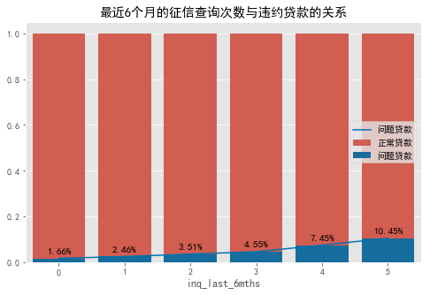

```python
plt.figure(figsize=(8,5))
sns.barplot(x=inq_last_6mths_status.index,y='total',data=inq_last_6mths_status,color='#e74c3c',label='正常贷款')
sns.barplot(x=inq_last_6mths_status.index,y='问题贷款',data=inq_last_6mths_status,color='#0072B2',label='问题贷款')
plt.twinx
plt.plot(inq_last_6mths_status.index,inq_last_6mths_status['问题贷款'],c='#0072B2')
for x,y in zip(inq_last_6mths_status.index,inq_last_6mths_status['问题贷款']):
    plt.text(x,y+0.02,'%.2f%%' % (y*100),ha='center',fontsize=11)
plt.ylabel('')
plt.legend(loc=7)
plt.title('最近6个月的征信查询次数与违约贷款的关系')
plt.show()
```

- 最近6个月的征信查询次数越多，表明客户资金状况越紧张，贷款违约的风险越大，违约率的上升趋势显著，查询次数为4次的违约率为7.45%，查询次数为5次的违约率高达10.45%。

```python
acc_now_delinq_status = loan.pivot_table(index='acc_now_delinq',columns='loan_status_trans',values='loan_status',
                    aggfunc='count').apply(lambda x:x/x.sum(),axis=1)
acc_now_delinq_status['total'] = acc_now_delinq_status['正常贷款'] + acc_now_delinq_status['问题贷款']
acc_now_delinq_status
```

| loan_status_trans acc_now_delinq | 正常贷款 | 问题贷款 | total |
| --- | --- | --- | --- |
| 0 | 0.979358 | 0.020642 | 1.0 |
| 1 | 0.884615 | 0.115385 | 1.0 |

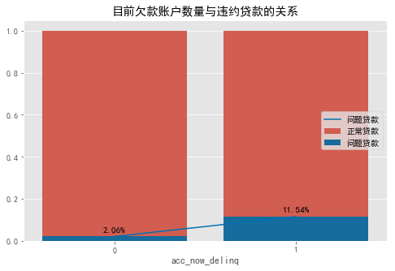

```python
plt.figure(figsize=(8,5))
sns.barplot(x=acc_now_delinq_status.index,y='total',data=acc_now_delinq_status,color='#e74c3c',label='正常贷款')
sns.barplot(x=acc_now_delinq_status.index,y='问题贷款',data=acc_now_delinq_status,color='#0072B2',label='问题贷款')
plt.twinx
plt.plot(acc_now_delinq_status.index,acc_now_delinq_status['问题贷款'],c='#0072B2')
for x,y in zip(acc_now_delinq_status.index,acc_now_delinq_status['问题贷款']):
    plt.text(x,y+0.02,'%.2f%%' % (y*100),ha='center',fontsize=11)
plt.ylabel('')
plt.legend(loc=7)
plt.title('目前欠款账户数量与违约贷款的关系')
plt.show()
```

- 目前存在欠款账户的客户资金状况堪忧，贷款违约的风险较大，违约率高达11.54%。

#### 3.3.5 客户信用记录与违约贷款的关系

```python
loan['delinq_2yrs_trans'] = loan['delinq_2yrs'].apply(lambda x:1 if x>0 else 0)
```

```python
delinq_2yrs_status = loan.pivot_table(index='delinq_2yrs_trans',columns='loan_status_trans',values='loan_status',
                    aggfunc='count').apply(lambda x:x/x.sum(),axis=1).reset_index()
delinq_2yrs_trans = {'delinq_2yrs_trans':{0:'0次',1:'≥1次'}}
delinq_2yrs_status.replace(delinq_2yrs_trans,inplace=True)
delinq_2yrs_status['total'] = delinq_2yrs_status['正常贷款'] + delinq_2yrs_status['问题贷款']
delinq_2yrs_status
```

| loan_status_trans | delinq_2yrs_trans | 正常贷款 | 问题贷款 | total |
| --- | --- | --- | --- | --- |
| 0 | 0次 | 0.980538 | 0.019462 | 1.0 |
| 1 | ≥1次 | 0.972414 | 0.027586 | 1.0 |

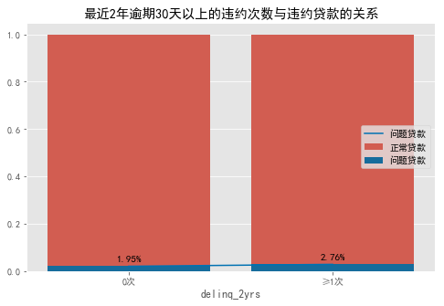

```python
plt.figure(figsize=(8,5))
sns.barplot(x='delinq_2yrs_trans',y='total',data=delinq_2yrs_status,color='#e74c3c',label='正常贷款')
sns.barplot(x='delinq_2yrs_trans',y='问题贷款',data=delinq_2yrs_status,color='#0072B2',label='问题贷款')
plt.twinx
plt.plot(delinq_2yrs_status.index,delinq_2yrs_status['问题贷款'],c='#0072B2')
for x,y in zip(delinq_2yrs_status.index,delinq_2yrs_status['问题贷款']):
    plt.text(x,y+0.02,'%.2f%%' % (y*100),ha='center',fontsize=11)
plt.ylabel('')
plt.xlabel('delinq_2yrs')
plt.legend(loc=7)
plt.title('最近2年逾期30天以上的违约次数与违约贷款的关系')
plt.show()
```

- 最近2年曾经逾期30天以上的贷款客户违约风险较大，违约率为2.76%，高于违约次数为0次的客户。

```python
loan['chargeoff_within_12_mths_trans'] = loan['chargeoff_within_12_mths'].apply(lambda x:1 if x>0 else 0)
```

```python
chargeoff_within_12_mths_status = loan.pivot_table(index='chargeoff_within_12_mths_trans',columns='loan_status_trans',values='loan_status',
                    aggfunc='count').apply(lambda x:x/x.sum(),axis=1).reset_index()
chargeoff_within_12_mths_trans = {'chargeoff_within_12_mths_trans':{0:'0次',1:'≥1次'}}
chargeoff_within_12_mths_status.replace(chargeoff_within_12_mths_trans,inplace=True)
chargeoff_within_12_mths_status['total'] = chargeoff_within_12_mths_status['正常贷款'] + chargeoff_within_12_mths_status['问题贷款']
chargeoff_within_12_mths_status
```

| loan_status_trans | chargeoff_within_12_mths_trans | 正常贷款 | 问题贷款 | total |
| --- | --- | --- | --- | --- |
| 0 | 0次 | 0.979417 | 0.020583 | 1.0 |
| 1 | ≥1次 | 0.968373 | 0.031627 | 1.0 |

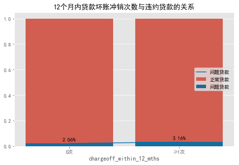

```python
plt.figure(figsize=(8,5))
sns.barplot(x='chargeoff_within_12_mths_trans',y='total',data=chargeoff_within_12_mths_status,color='#e74c3c',label='正常贷款')
sns.barplot(x='chargeoff_within_12_mths_trans',y='问题贷款',data=chargeoff_within_12_mths_status,color='#0072B2',label='问题贷款')
plt.twinx
plt.plot(chargeoff_within_12_mths_status.index,chargeoff_within_12_mths_status['问题贷款'],c='#0072B2')
for x,y in zip(chargeoff_within_12_mths_status.index,chargeoff_within_12_mths_status['问题贷款']):
    plt.text(x,y+0.02,'%.2f%%' % (y*100),ha='center',fontsize=11)
plt.ylabel('')
plt.xlabel('chargeoff_within_12_mths')
plt.legend(loc=7)
plt.title('12个月内贷款坏账冲销次数与违约贷款的关系')
plt.show()
```

- 12个月内曾经有贷款坏账冲销的客户违约风险较大，违约率为3.16%，高于坏账冲销次数为0次的客户。

#### 3.3.6 贷款违约影响因素分析总结

- 综合以上分析，贷款违约影响因素有以下特点：
  - 贷款金额、利率越高，期限越长，贷款违约的风险越大；
  - 贷款信用评级等级越低，贷款违约的可能性越大；
  - 客户的收入、资金、信用状况会影响违约风险，违约贷款的客户收入主要集中于低收入水平，近期存在频繁征信查询记录和违约事项的违约风险较大；
  - 客户的工作年限对违约率的影响差别不大，贷款申请信息不完整的客户违约风险较大。

## 四、构建贷款违约预测模型

### 4.1 算法选择

- 本文对贷款违约影响因素进行探索分析，构建模型预测贷款是否会违约，已知预测的目标变量为贷款状态——是否会违约，属于二元分类问题，选择监督学习中的分类算法——逻辑回归。逻辑回归是应用非常广泛的一个分类机器学习算法，它将数据拟合到一个logistic函数中，从而能够完成对事件发生的概率进行预测。

### 4.2 数据处理

#### 4.2.1 数据概览

```python
data = pd.read_csv('LoanStats_2018Q1Q2_Individual.csv',encoding='utf8')
```

```python
data.head()
```

|  | loan_amnt | term | int_rate | installment | grade | emp_title | emp_length | home_ownership | annual_inc | verification_status | ... | num_tl_90g_dpd_24m | num_tl_op_past_12m | pct_tl_nvr_dlq | percent_bc_gt_75 | pub_rec_bankruptcies | tax_liens | tot_hi_cred_lim | total_bal_ex_mort | total_bc_limit | total_il_high_credit_limit |
| --- | --- | --- | --- | --- | --- | --- | --- | --- | --- | --- | --- | --- | --- | --- | --- | --- | --- | --- | --- | --- | --- |
| 0 | 7200.0 | 36 months | 13.58% | 244.62 | C | Electronic Health Services trainer | 8 years | RENT | 51738.0 | Source Verified | ... | 0.0 | 8.0 | 100.0 | 0.0 | 1.0 | 0.0 | 15094.0 | 8126.0 | 4500.0 | 5394.0 |
| 1 | 12000.0 | 36 months | 6.07% | 365.45 | A | Associate Vice President | 10+ years | MORTGAGE | 240000.0 | Source Verified | ... | 0.0 | 2.0 | 95.5 | 12.5 | 0.0 | 0.0 | 480251.0 | 82258.0 | 117600.0 | 65651.0 |
| 2 | 3100.0 | 36 months | 9.43% | 99.21 | B | Manager | 10+ years | MORTGAGE | 85000.0 | Not Verified | ... | 1.0 | 1.0 | 90.6 | 0.0 | 0.0 | 0.0 | 344165.0 | 59039.0 | 20900.0 | 28337.0 |
| 3 | 3200.0 | 36 months | 7.96% | 100.22 | A | Lineman | 1 year | RENT | 42000.0 | Source Verified | ... | 0.0 | 2.0 | 100.0 | 0.0 | 0.0 | 0.0 | 19350.0 | 14533.0 | 6100.0 | 13250.0 |
| 4 | 11000.0 | 36 months | 7.34% | 341.37 | A | MPF | 10+ years | OWN | 100000.0 | Not Verified | ... | 0.0 | 3.0 | 100.0 | 50.0 | 0.0 | 0.0 | 120356.0 | 62727.0 | 32500.0 | 54556.0 |

5 rows × 76 columns

```python
data.info()
```

```
<class 'pandas.core.frame.DataFrame'>
RangeIndex: 204218 entries, 0 to 204217
Data columns (total 76 columns):
loan_amnt                     204218 non-null float64
term                          204218 non-null object
int_rate                      204218 non-null object
installment                   204218 non-null float64
grade                         204218 non-null object
emp_title                     188916 non-null object
emp_length                    204218 non-null object
home_ownership                204218 non-null object
annual_inc                    204218 non-null float64
verification_status           204218 non-null object
issue_d                       204218 non-null object
loan_status                   204218 non-null object
title                         204218 non-null object
addr_state                    204218 non-null object
dti                           204218 non-null float64
delinq_2yrs                   204218 non-null float64
inq_last_6mths                204218 non-null float64
open_acc                      204218 non-null float64
pub_rec                       204218 non-null float64
revol_bal                     204218 non-null float64
revol_util                    203992 non-null object
total_acc                     204218 non-null float64
collections_12_mths_ex_med    204218 non-null float64
application_type              204218 non-null object
acc_now_delinq                204218 non-null float64
tot_coll_amt                  204218 non-null float64
tot_cur_bal                   204218 non-null float64
open_acc_6m                   204218 non-null float64
open_act_il                   204218 non-null float64
open_il_12m                   204218 non-null float64
open_il_24m                   204218 non-null float64
mths_since_rcnt_il            196272 non-null float64
total_bal_il                  204218 non-null float64
il_util                       170369 non-null float64
open_rv_12m                   204218 non-null float64
open_rv_24m                   204218 non-null float64
max_bal_bc                    204218 non-null float64
```

[output cut: 26 more lines]

```
num_rev_tl_bal_gt_0           204218 non-null float64
num_sats                      204218 non-null float64
num_tl_30dpd                  204218 non-null float64
num_tl_90g_dpd_24m            204218 non-null float64
num_tl_op_past_12m            204218 non-null float64
pct_tl_nvr_dlq                204217 non-null float64
percent_bc_gt_75              201778 non-null float64
pub_rec_bankruptcies          204218 non-null float64
tax_liens                     204218 non-null float64
tot_hi_cred_lim               204218 non-null float64
total_bal_ex_mort             204218 non-null float64
total_bc_limit                204218 non-null float64
total_il_high_credit_limit    204218 non-null float64
dtypes: float64(63), object(13)
memory usage: 118.4+ MB
```

- 个人贷款数据集共有204218行，76个变量，数据类型为浮点数和字符串类型，结合上文分析，将分类过多、包含重复行为信息等对模型预测意义不大的变量删除，包括发放贷款月份、客户职业、所在州、申请类型、贷款原因和历史开户、查询时间。

```python
data.drop(['emp_title','issue_d','title','addr_state','application_type','mths_since_rcnt_il','mo_sin_old_il_acct','mo_sin_old_rev_tl_op',
          'mo_sin_rcnt_rev_tl_op','mo_sin_rcnt_tl','mths_since_recent_bc','mths_since_recent_inq'],axis=1,inplace=True)
```

#### 4.2.2 数据类型转换

```python
data.select_dtypes(include=['object']).describe().T.assign(isnull_pct = data.isnull().sum()/len(data))
```

|  | count | unique | top | freq | isnull_pct |
| --- | --- | --- | --- | --- | --- |
| term | 204218 | 2 | 36 months | 146863 | 0.000000 |
| int_rate | 204218 | 75 | 5.31% | 7343 | 0.000000 |
| grade | 204218 | 7 | B | 60931 | 0.000000 |
| emp_length | 204218 | 12 | 10+ years | 68129 | 0.000000 |
| home_ownership | 204218 | 4 | MORTGAGE | 91415 | 0.000000 |
| verification_status | 204218 | 3 | Source Verified | 85098 | 0.000000 |
| loan_status | 204218 | 6 | Current | 189345 | 0.000000 |
| revol_util | 203992 | 1089 | 0% | 2166 | 0.001107 |

- 对分类变量进行数据类型转换，目标变量中，正常贷款编码为0，违约贷款为1。

```python
data.term = data.term.str.rstrip(' months').astype('int64')
data.int_rate = data.int_rate.str.rstrip('%').astype('float')
data.revol_util = data.revol_util.str.rstrip('%').astype('float')
```

```python
mapping_dict = {
    'loan_status':{
        'Current':0,
        'Fully Paid':0,
        'In Grace Period':1,
        'Late (16-30 days)':1,
        'Late (31-120 days)':1,
        'Charged Off':1 },
    'emp_length':{
        'n/a':0,'< 1 year':1,'1 year':2,'2 years':3,'3 years':4,'4 years':5,'5 years':6,
        '6 years':7,'7 years':8,'8 years':9,'9 years':10,'10+ years':11 },
    'grade':{
        'A':0,'B':1,'C':2,'D':3,'E':4,'F':5,'G':6 },
    'home_ownership':{
        'ANY':0,'RENT':1,'OWN':2,'MORTGAGE':3},
    'verification_status':{
        'Not Verified':0,'Source Verified':1,'Verified':2}
}
data.replace(mapping_dict,inplace=True)
```

#### 4.2.3 缺失值处理

```python
isnull_pct = data.isnull().sum()/len(data)
null_col = list(isnull_pct[isnull_pct>0].index)
data[null_col].describe().T.assign(isnull_pct = data[null_col].isnull().sum()/len(data))
```

|  | count | mean | std | min | 25% | 50% | 75% | max | isnull_pct |
| --- | --- | --- | --- | --- | --- | --- | --- | --- | --- |
| revol_util | 203992.0 | 43.197016 | 24.871777 | 0.0 | 23.6 | 41.3 | 61.4 | 175.0 | 0.001107 |
| il_util | 170369.0 | 67.935951 | 24.100725 | 0.0 | 53.0 | 70.0 | 85.0 | 1000.0 | 0.165749 |
| all_util | 204180.0 | 53.664218 | 21.288008 | 0.0 | 39.0 | 54.0 | 69.0 | 239.0 | 0.000186 |
| avg_cur_bal | 204205.0 | 12887.180657 | 16638.605587 | 0.0 | 2719.0 | 6355.0 | 17624.0 | 620531.0 | 0.000064 |
| bc_open_to_buy | 201783.0 | 15051.774139 | 19560.872412 | 0.0 | 2878.0 | 8222.0 | 19637.5 | 493101.0 | 0.011924 |
| bc_util | 201699.0 | 49.118925 | 28.959131 | 0.0 | 25.2 | 47.8 | 73.5 | 175.0 | 0.012335 |
| pct_tl_nvr_dlq | 204217.0 | 94.462401 | 9.237502 | 0.0 | 92.3 | 100.0 | 100.0 | 100.0 | 0.000005 |
| percent_bc_gt_75 | 201778.0 | 32.048827 | 34.734690 | 0.0 | 0.0 | 22.2 | 50.0 | 100.0 | 0.011948 |

- 对数值变量的缺失值，赋值为0进行填充。

```python
data.fillna(0,inplace=True)
```

```python
data.info()
```

```
<class 'pandas.core.frame.DataFrame'>
RangeIndex: 204218 entries, 0 to 204217
Data columns (total 64 columns):
loan_amnt                     204218 non-null float64
term                          204218 non-null int64
int_rate                      204218 non-null float64
installment                   204218 non-null float64
grade                         204218 non-null int64
emp_length                    204218 non-null int64
home_ownership                204218 non-null int64
annual_inc                    204218 non-null float64
verification_status           204218 non-null int64
loan_status                   204218 non-null int64
dti                           204218 non-null float64
delinq_2yrs                   204218 non-null float64
inq_last_6mths                204218 non-null float64
open_acc                      204218 non-null float64
pub_rec                       204218 non-null float64
revol_bal                     204218 non-null float64
revol_util                    204218 non-null float64
total_acc                     204218 non-null float64
collections_12_mths_ex_med    204218 non-null float64
acc_now_delinq                204218 non-null float64
tot_coll_amt                  204218 non-null float64
tot_cur_bal                   204218 non-null float64
open_acc_6m                   204218 non-null float64
open_act_il                   204218 non-null float64
open_il_12m                   204218 non-null float64
open_il_24m                   204218 non-null float64
total_bal_il                  204218 non-null float64
il_util                       204218 non-null float64
open_rv_12m                   204218 non-null float64
open_rv_24m                   204218 non-null float64
max_bal_bc                    204218 non-null float64
all_util                      204218 non-null float64
total_rev_hi_lim              204218 non-null float64
inq_fi                        204218 non-null float64
total_cu_tl                   204218 non-null float64
inq_last_12m                  204218 non-null float64
acc_open_past_24mths          204218 non-null float64
```

[output cut: 14 more lines]

```
num_rev_tl_bal_gt_0           204218 non-null float64
num_sats                      204218 non-null float64
num_tl_30dpd                  204218 non-null float64
num_tl_90g_dpd_24m            204218 non-null float64
num_tl_op_past_12m            204218 non-null float64
pct_tl_nvr_dlq                204218 non-null float64
percent_bc_gt_75              204218 non-null float64
pub_rec_bankruptcies          204218 non-null float64
tax_liens                     204218 non-null float64
tot_hi_cred_lim               204218 non-null float64
total_bal_ex_mort             204218 non-null float64
total_bc_limit                204218 non-null float64
total_il_high_credit_limit    204218 non-null float64
dtypes: float64(58), int64(6)
memory usage: 99.7 MB
```

- 处理数据后，数据集共有204218行，1个目标变量，63个特征变量，不存在缺失值。

### 4.3 模型特征选择

#### 4.3.1 递归特征消除 (Recursive Feature Elimination)

- 递归特征消除：对特征含有权重的预测模型，RFE通过递归减少最小绝对值权重的特征，选择与目标相关性高的特征。

```python
from sklearn.feature_selection import RFE
from sklearn.linear_model import LogisticRegression
```

```python
columns = data.columns
features_columns = columns.drop('loan_status')
features = data[features_columns]
```

```python
target = data['loan_status']
```

```python
estimator = LogisticRegression(class_weight='balanced')
rfe = RFE(estimator=estimator,n_features_to_select=30).fit(features,target)
```

```python
features_chosed = features_columns[rfe.support_]
```

```python
features_chosed
```

```
Index(['int_rate', 'grade', 'home_ownership', 'verification_status',
       'delinq_2yrs', 'inq_last_6mths', 'open_acc', 'pub_rec', 'total_acc',
       'collections_12_mths_ex_med', 'open_acc_6m', 'open_il_12m',
       'open_il_24m', 'open_rv_12m', 'open_rv_24m', 'inq_fi', 'total_cu_tl',
       'acc_open_past_24mths', 'chargeoff_within_12_mths', 'mort_acc',
       'num_actv_bc_tl', 'num_actv_rev_tl', 'num_bc_sats', 'num_il_tl',
       'num_rev_accts', 'num_rev_tl_bal_gt_0', 'num_sats',
       'num_tl_90g_dpd_24m', 'num_tl_op_past_12m', 'tax_liens'],
      dtype='object')
```

```python
len(features_chosed)
```

```
30
```

- 通过递归特征消除，筛选出30个特征变量。

#### 4.3.2 皮尔逊相关系数 (Pearson Correlation)

- 当特征变量之间高度相关时（共线性），模型的预测能力会降低，需根据业务实际筛选过滤相关变量。
- 皮尔逊相关系数衡量变量之间的线性相关程度，取值范围为[-1,1]，相关系数绝对值越大表明相关性越强。

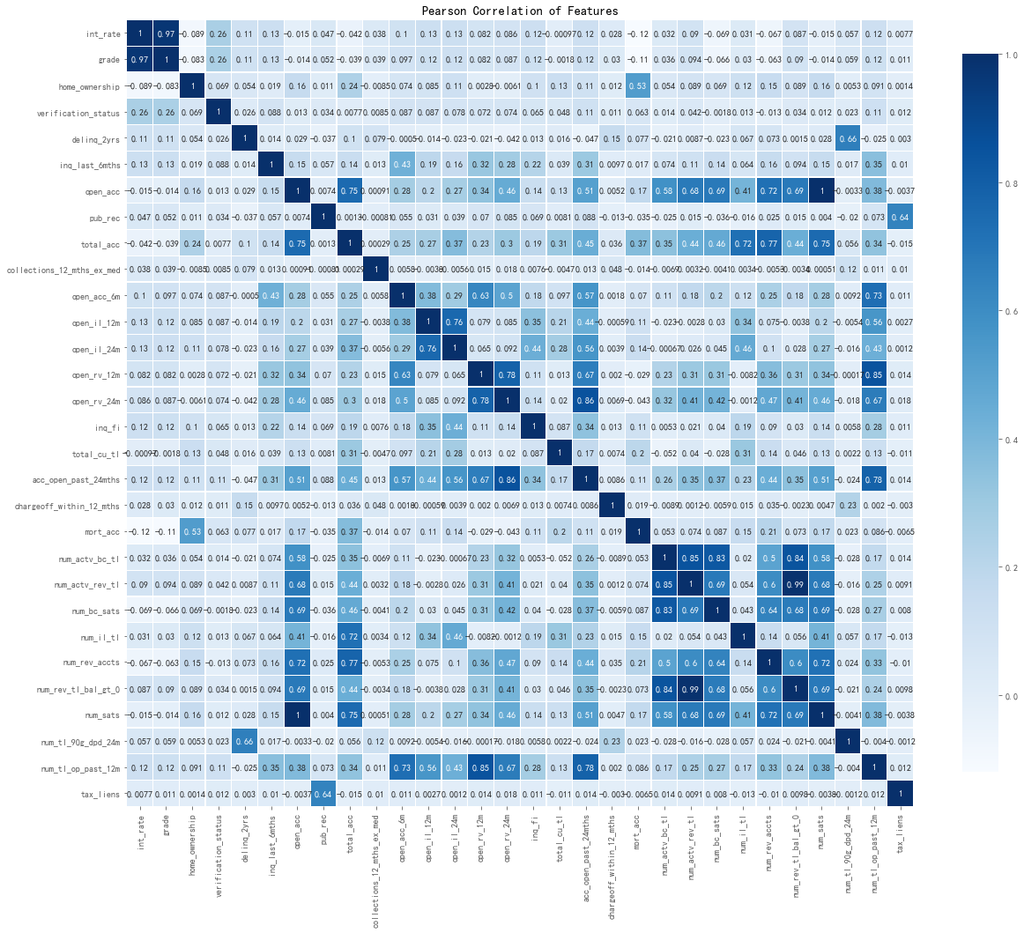

```python
plt.figure(figsize=(20,20))
sns.heatmap(data[features_chosed].corr(),linewidths=0.25,square=True,cmap='Blues',linecolor='w',cbar_kws={'shrink': .75},annot=True)
plt.title('Pearson Correlation of Features')
plt.show()
```

- 通过皮尔逊相关系数分析变量之间的关系，筛选剔除相关系数超过0.6的变量，进一步选择特征变量。

```python
drop_columns = ['grade','open_acc','num_tl_op_past_12m','acc_open_past_24mths','tax_liens','num_tl_90g_dpd_24m',
               'num_actv_bc_tl','num_bc_sats','num_il_tl','num_rev_accts','num_rev_tl_bal_gt_0','num_sats',
               'open_rv_12m','open_il_24m']
```

```python
col_new = features_chosed.drop(drop_columns)
```

```python
col_new
```

```
Index(['int_rate', 'home_ownership', 'verification_status', 'delinq_2yrs',
       'inq_last_6mths', 'pub_rec', 'total_acc', 'collections_12_mths_ex_med',
       'open_acc_6m', 'open_il_12m', 'open_rv_24m', 'inq_fi', 'total_cu_tl',
       'chargeoff_within_12_mths', 'mort_acc', 'num_actv_rev_tl'],
      dtype='object')
```

```python
len(col_new)
```

```
16
```

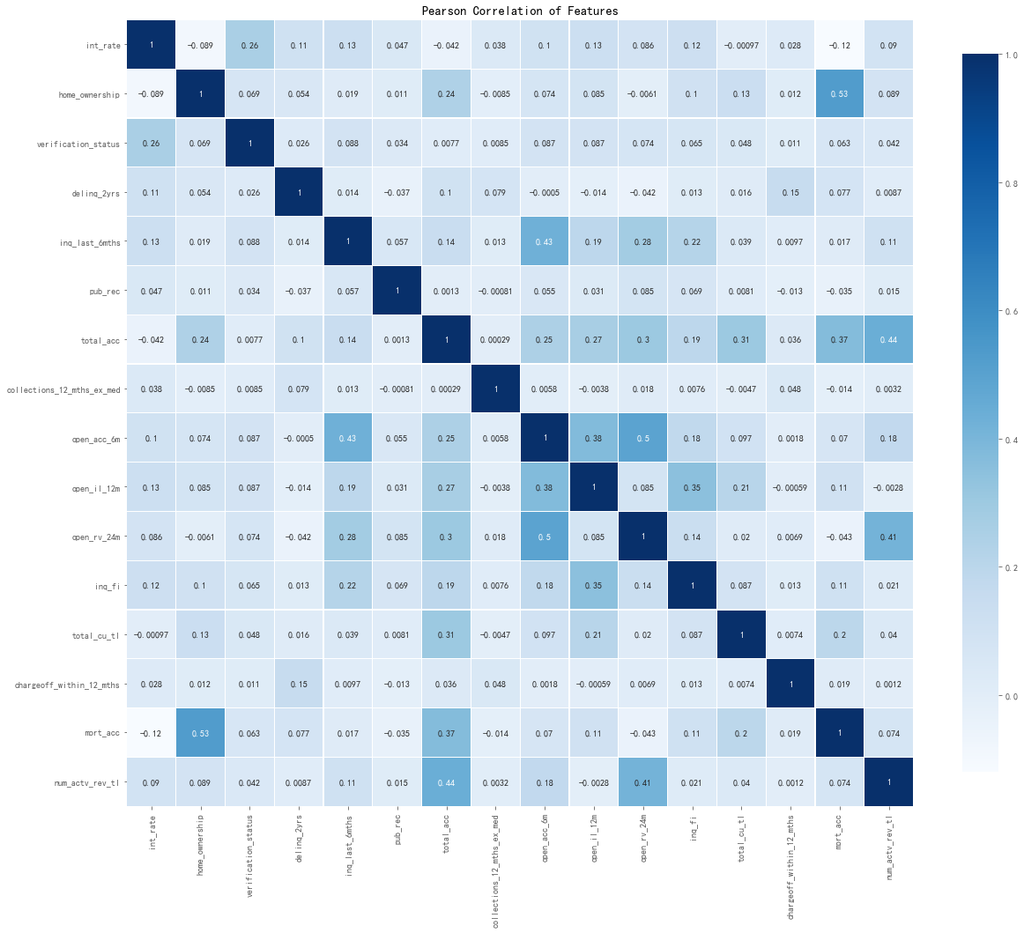

```python
plt.figure(figsize=(20,20))
sns.heatmap(data[col_new].corr(),linewidths=0.25,square=True,cmap='Blues',linecolor='w',cbar_kws={'shrink': .75},annot=True)
plt.title('Pearson Correlation of Features')
plt.show()
```

- 筛选变量后，共选择了16个特征变量，皮尔逊相关系数如上图所示。

### 4.4 建立训练数据集和测试数据集

- 将数据集以8:2的比例分成训练数据集和测试数据集。

```python
from sklearn.model_selection import train_test_split
```

```python
features_new = data[col_new]
```

```python
X_train,X_test,y_train,y_test = train_test_split(features_new,target,train_size=.8)
```

```python
print('训练数据集特征：',X_train.shape)
print('训练数据集标签：',y_train.shape)
print('测试数据集特征：',X_test.shape)
print('测试数据集标签：',y_test.shape)
```

```
训练数据集特征： (163374, 16)
训练数据集标签： (163374,)
测试数据集特征： (40844, 16)
测试数据集标签： (40844,)
```

### 4.5 模型训练

- 处理样本不均衡：目标变量中正常和违约两个类别的数据量差别较大，将参数class_weight设置为balanced。
- 交叉验证：k折交叉验证，将训练数据集划分为k等份，对于每一份数据集，其中k-1份用作训练集，单独一份用作验证集，进行k次训练和测试，在一定程度上减少过拟合，优化模型的预测性能。

```python
from sklearn.model_selection import KFold,cross_val_predict
from sklearn.metrics import accuracy_score
```

```python
lr = LogisticRegression(class_weight='balanced')
kf = KFold(n_splits=5)
```

```python
lr.fit(X_train,y_train)
```

```
LogisticRegression(C=1.0, class_weight='balanced', dual=False,
          fit_intercept=True, intercept_scaling=1, max_iter=100,
          multi_class='warn', n_jobs=None, penalty='l2', random_state=None,
          solver='warn', tol=0.0001, verbose=0, warm_start=False)
```

```python
prediction_train = cross_val_predict(lr,X_train,y_train,cv=kf)
```

```python
prediction_train = pd.Series(prediction_train)
```

```python
accuracy_score(y_train,prediction_train)
```

```
0.6749482781837991
```

- 训练数据集的预测结果准确率为67.49%。

### 4.6 模型评估

- 混淆矩阵：混淆矩阵是机器学习中对监督学习的分类算法进行评估的常用工具，将真实值与预测值对比，利用评估指标反映模型分类的效果，矩阵的行表示真实类别，矩阵的列表示预测类别。
  - 对于二分类问题，混淆矩阵的四个矩阵元素分别为：
    - True Positive(TP)：真正例，真实类别为正例（正常），预测类别为正例（正常）；
    - False Positive(FP)：假正例，真实类别为负例（违约），预测类别为正例（正常）；
    - False Negative(FN)：假负例，真实类别为正例（正常），预测类别为负例（违约）；
    - True Negative(TN)：真负例，真实类别为负例（违约），预测类别为负例（违约）。
  - 混淆矩阵评估指标：
    - 准确率：Accuracy(ACC) = (TP+TN)/(TP+TN+FP+FN)，预测正确的样本数占总样本数的比例；
    - 精确率：Precision(PPV,Positive predictive value) = TP/(TP+FP)，预测为正例的样本中，预测正确的样本所占比例；
    - 召回率：Recall(TPR,True positive rate) = TP/(TP+FN)，真实为正例的样本中，正确预测为正例的样本所占比例；
    - 假正率：Fall-out(FPR,False positive rate) = FP/(FP+TN)，真实为负例的样本中，错误预测为正例的样本所占比例。

```python
from sklearn.metrics import confusion_matrix
```

```python
prediction_test = cross_val_predict(lr,X_test,y_test,cv=kf)
```

```python
prediction_test = pd.Series(prediction_test)
```

```python
accuracy_score(y_test,prediction_test)
```

```
0.68279306630104786
```

```python
confusion_matrix_test = confusion_matrix(y_test,prediction_test)
confusion_matrix_test
```

```
array([[27364, 12644],
       [  312,   524]], dtype=int64)
```

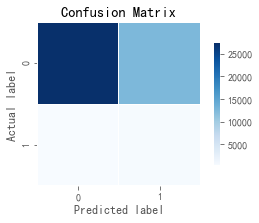

```python
plt.figure(figsize=(5,3))
sns.heatmap(confusion_matrix_test,linewidths=0.25,square=True,cmap='Blues',linecolor='w',cbar_kws={'shrink': .75},annot=False)
plt.title('Confusion Matrix')
plt.ylabel('Actual label')
plt.xlabel('Predicted label')
plt.show()
```

- 模型预测结果的准确率为68.28%，精确率为98.87%，由于正负样本数量极度不均衡，准确率和精确率具有一定的误导性，不能客观反映分类效果；
- 召回率为68.40%，一般情况下，召回率越高，有更多的正例样本被预测正确，模型预测效果越好；
- 假正率为37.32%，一般情况下，假正率越低，错误预测为正例的负例样本越少，模型预测效果越好；
- 模型可进一步调整和优化。

## 五、总结与建议

### 5.1 总结

- **LendingClub营收较为依赖贷款交易规模：**
  - LendingClub的营业收入主要是贷款交易费、投资服务费和账户管理费，根据2017年财务报告显示，贷款交易费为4.49亿美元，占比78.08%，投资服务费为0.87亿美元，占比15.16%，LendingClub营收以贷款交易费为主，较为依赖贷款交易规模。
- **LendingClub内部风险控制机制较为成熟：**
  - 个人贷款审批流程中，LendingClub风险控制机制基于FICO信用评分数据，贷款申请人提交申请后，平台会根据标准进行审查，申请人准入条件如下：
    - FICO信用评分不低于660分；
    - 债务收入比低于40%；
    - 信用报告中，至少有两个账户正常使用中；
    - 最近6个月征信查询次数不超过5次；
    - 提供至少36个月的信用记录。
- **LendingClub实行差异化风险定价策略，信用评级模型较为成熟：**
  - 对于标准个人贷款业务，LendingClub综合考评贷款申请人的FICO分数、征信记录以及贷款申请中的信用风险指标信息，核查申请人的资产、收入状况，利用专有的信用评级模型对申请人进行风险评估，并结合申请贷款的金额和期限，确定贷款信用评级和贷款利率。贷款信用评级分为A-G七个等级，每个等级下设置了五个子等级。LendingClub设定利率时综合考虑市场基准和信用风险，实行差异化风险定价策略，贷款信用评级等级越低，贷款利率越高。
  - 贷款信用评级等级越低，贷款违约率越高，LendingClub信用评级模型较为成熟。

### 5.2 建议

- **从风险识别的角度来看：**
  - LendingClub线上风控模式较为依赖信用评分或年收入等量化指标，对于风险评估，还应考虑美国消费者提前消费、过度消费的观念和季节性因素的影响。收入越高的个人消费支出越大，可能更容易陷入资不抵债的困境，个人申请贷款主要用于债务合并、信用卡还款，贷款客户财务风险较大。在第四季度，消费者对假期消费带来的财务压力，导致贷款逾期、坏账的可能性增大。
- **从信用评级标准的角度来看：**
  - 根据2017年财务报告显示，LendingClub2015-2017年贷款交易规模和营业收入增长缓慢，平台通过调整信用评级标准和定价策略以维持交易规模发展，贷款逾期率自2015年起超过美国银行消费贷款平均水平。LendingClub保持业务增长态势的同时也应落实风控机制，保证贷款质量，控制违约风险，关注经营效益。
- **从高风险客群的角度来看：**
  - 一般情况下，P2P贷款客户主要为难以达到传统银行信贷标准的高风险人群，信贷资金的回款取决于客户的还款能力和还款意愿。LendingClub应根据不同贷款信用评级的客户特征信息，对高违约风险的细分客群加强甄别与监察，及时预警贷款逾期的风险，积极开展催收工作，降低坏账风险。